# Data Mining Final Phase

# Problem

In today’s dynamic job market, accurately predicting salaries is a crucial aspect for both job seekers and employers. The challenge lies in comprehending and understanding the various factors that contribute to an individual’s earning potential. Our aim in this project is to develop a robust and precise salary prediction model based on various features such as education level, workclass, occupation, and so on.

# Data Mining Task

Our overall aim is to create a reliable salary prediction model using both classification and clustering techniques. This model can assist employees and employers in making more informed decisions about compensation and hiring.

Classification: We will classify employees into different groups based on their personal and professional characteristics to build a predictive model that accurately categorizes individuals into two groups. This will allow us to predict the salary of new employees based on some factors , for example age, sex, salary … etc

Clustering: We will divide the employees into several groups based on their characteristics in the attributes value. This will allow us to identify groups of employees who are likely to have similar salaries without using the class label.

We believe that by using these data mining tasks, we can build a model that can accurately predict the salary of an employee.

# Data

## Goal of Collecting this Dataset

The goal of our dataset is to predict whether or not the yearly salary exceeds $50,000 and cluster individuals based on their salaries. Salary is a great source of motivation for employees, and as a result, we believe that salary prediction and clustering can be helpful to both employees and their employers, as it can roughly calculate the expected salaries, identify salary trends, and the relationship between salaries and various factors. This information can be helpful to both employees and employers in negotiating for a fair salary, making better hiring decisions, and identifying areas for improvement.

## Source of the Dataset

The dataset was obtained from Kaggle. https://www.kaggle.com/datasets/ayessa/salary-prediction-classification

## General information:

Our dataset contains 15 attributes and 32,561 objects. The class label is “salary”.

## Class Label

Our attributes are the following:

| Attribute name | Attribute type | **Description** |
| --- | --- | --- |
| Age | integer | The person’s age in years. |
| workclass | categorical | Represents the employment status. |
| fnlwgt | integer | The final weight of how much of the population it represents. |
| education | categorical | Highest level of education. |
| education-num | integer | Highest level of education in numerical form. |
| marital-status | categorical | Represents the marital status. |
| occupation | categorical | Represents the occupation of the individual. |
| relationship | categorical | Represents the relationship status. |
| race | categorical | Represents the person’s race. |
| sex | binary | The person’s gender. |
| capital-gain | integer | Represents the capital gain. |
| capital-loss | integer | Represents the capital loss. |
| hours . per.week | continuous | Represents the hours the person works per week. |
| native -country | categorical | The person’s country. |
| salary | binary | The class label; it indicates whether the person makes more or less than $50,000. |

### Call the dataset

```r
dataset=read.csv('salary.csv')
```

This a sample of our ‘salary’ dataset

```r
head(dataset)
```

```
##   age         workclass fnlwgt  education education.num      marital.status
## 1  39         State-gov  77516  Bachelors            13       Never-married
## 2  50  Self-emp-not-inc  83311  Bachelors            13  Married-civ-spouse
## 3  38           Private 215646    HS-grad             9            Divorced
## 4  53           Private 234721       11th             7  Married-civ-spouse
## 5  28           Private 338409  Bachelors            13  Married-civ-spouse
## 6  37           Private 284582    Masters            14  Married-civ-spouse
##           occupation   relationship   race     sex capital.gain capital.loss
## 1       Adm-clerical  Not-in-family  White    Male         2174            0
## 2    Exec-managerial        Husband  White    Male            0            0
## 3  Handlers-cleaners  Not-in-family  White    Male            0            0
## 4  Handlers-cleaners        Husband  Black    Male            0            0
## 5     Prof-specialty           Wife  Black  Female            0            0
## 6    Exec-managerial           Wife  White  Female            0            0
##   hours.per.week native.country salary
## 1             40  United-States  <=50K
## 2             13  United-States  <=50K
## 3             40  United-States  <=50K
## 4             40  United-States  <=50K
## 5             40           Cuba  <=50K
## 6             40  United-States  <=50K
```

Create a new column called num_salary to transform the binary attribute into numerical to use it better as it it the class label

```r
dataset$num_salary <-  as.integer(factor(dataset$salary))
dataset$num_salary=cut(dataset$num_salary,breaks= c(1,2, Inf),labels=c(0, 1),right = FALSE)
dataset$num_salary=as.factor(dataset$num_salary)
```

### Installing the packages:

```r
install.packages("scatterplot3d", repos = "https://cran.r-project.org")
install.packages("dplyr", repos = "https://cran.r-project.org")
install.packages("ggplot2",  repos = "https://cran.r-project.org")
install.packages("colorspace",  repos = "https://cran.r-project.org")
```

### Reading libraries and the dataset

```r
library(ggplot2)
library(scatterplot3d)
library(dplyr)
library(readr)
```

### Statistical Measures

```r
summary(dataset$age)
```

```
##    Min. 1st Qu.  Median    Mean 3rd Qu.    Max.
##   17.00   28.00   37.00   38.58   48.00   90.00
```

```r
summary(dataset$hours.per.week)
```

```
##    Min. 1st Qu.  Median    Mean 3rd Qu.    Max.
##    1.00   40.00   40.00   40.44   45.00   99.00
```

```r
summary(dataset$fnlwgt)
```

```
##    Min. 1st Qu.  Median    Mean 3rd Qu.    Max.
##   12285  117827  178356  189778  237051 1484705
```

**Analysis:**

age: The mean has a value of 38.58, and the data range from 17 up to a maximum of 90.

hours.per.week: The mean has a value of 40.44. The median and 1st quartile have the same value, suggesting symmetry.

fnlwgt: The mean is 189778. 75% of the data falls below 237051. The mean being greater than the median suggests a right-skewed distribution.

### Missing Values

```r
sum(is.na(dataset))
```

```
## [1] 0
```

### Finding Outliers

Install the needed packages and libraries

```r
install.packages("outliers", repos = "https://cran.r-project.org")
library(outliers)
```

```r
OutAge = outlier(dataset$age, logical =TRUE)
Find_outlierAge = which(OutAge ==TRUE, arr.ind = TRUE)
```

```r
Outfnlwgt = outlier(dataset$fnlwgt, logical =TRUE)
Find_outlierFnlwgt = which(Outfnlwgt ==TRUE, arr.ind = TRUE)
```

```r
Outhours = outlier(dataset$hours.per.week, logical =TRUE)
Find_outlierHours = which(Outhours ==TRUE, arr.ind = TRUE)
```

### Boxplot

A boxplot is a visualization of the five-number summary.

The hours.per.week boxplot illustrates that there are 9008 outliers in the attribute.

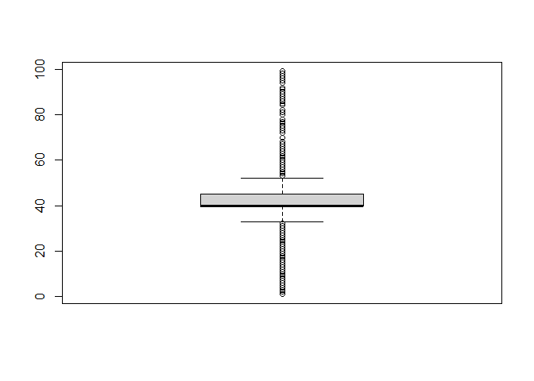

```r
boxplot(dataset$hours.per.week)
```

The age boxplot illustrates that there are 143 outliers in the attribute.

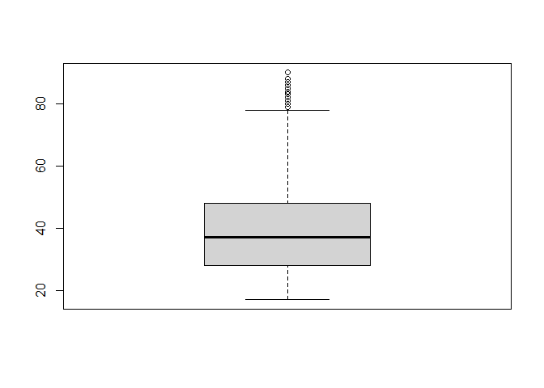

```r
 boxplot(dataset$age)
```

The fnlwgt boxplot illustrates that there is 992 outliers in the attribute.

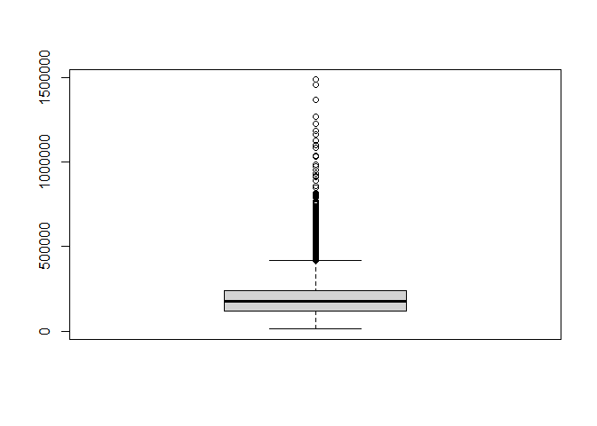

```r
boxplot(dataset$fnlwgt)
```

### Histograms

Histograms are graphs that show the frequency of numerical data using rectangles.The height of a rectangle represents the distribution frequency of a variable.[1]

The age histogram tells us that most of our observations are close in age, with a minority being older.

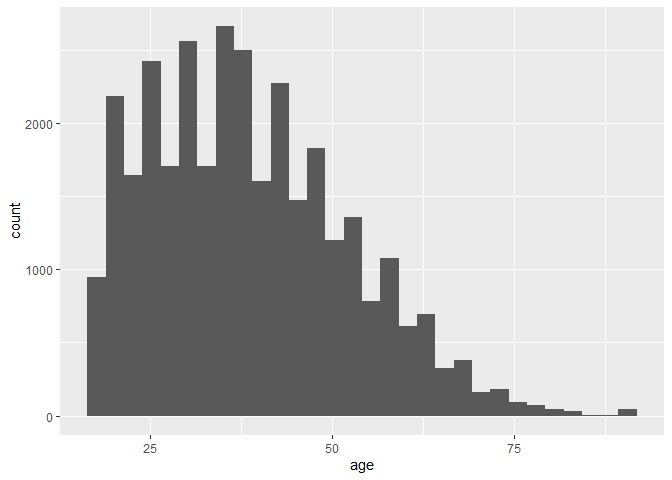

```r
# Histogram of the age variable
ggplot(dataset, aes(x = age)) +
  geom_histogram()
```

We see in the histogram for ‘hours.per.week’ that the overwhelming majority work 40 hours a week.

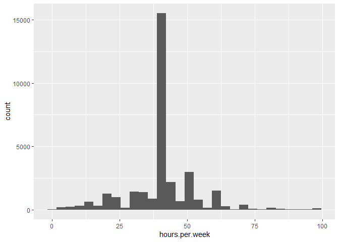

```r
# Histogram of the hours-per-week variable
ggplot(dataset, aes(x = hours.per.week)) +
  geom_histogram()
```

In the histogram for ‘fnlwgt’, we see that the majority (over 7000), is between 100000 and 200000.

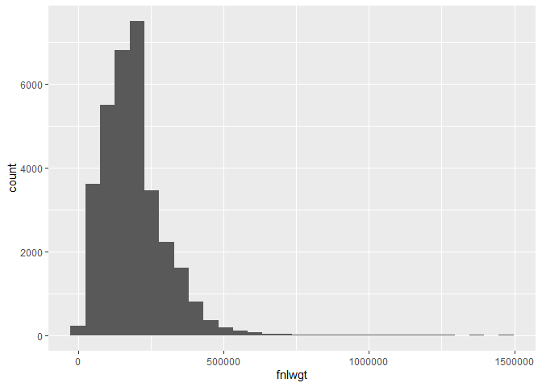

```r
# Histogram of the fnlwgt variable
ggplot(dataset, aes(x = fnlwgt)) +
  geom_histogram()
```

### Barplots

A barplot shows the relationship between a numeric and a categorical variable. Each entity of the categorical variable is represented as a bar. The size of the bar represents its numeric value.[2]

In the workclass barplot, we can see that majority belong to the workclass ‘Private’, while the rest were distributed among other workclass levels.

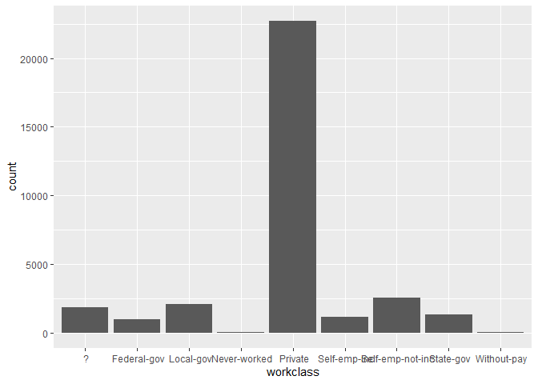

```r
# Bar plot of the workclass variable
ggplot(dataset, aes(x = workclass)) + geom_bar()
```

In marital.status barplot, the majority had a ‘Married-civ-spouse’ status, followed closely by ‘Never-married’, then level ‘Divorced’. ‘Widowed’ and ‘Separated’ were fairly close, and ‘Married-AF-spouse’ was the minority.

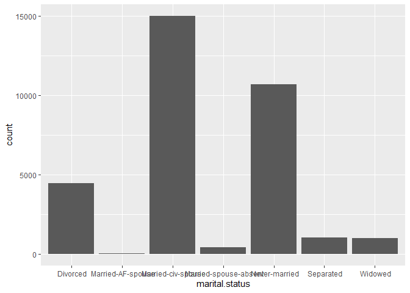

```r
# Bar plot of the marital-status variable
ggplot(dataset, aes(x = marital.status)) + geom_bar()
```

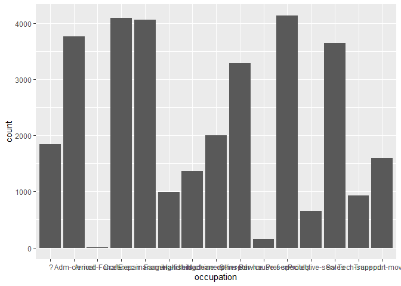

```r
# Bar plot of the occupation variable
ggplot(dataset, aes(x = occupation)) + geom_bar()
```

In the relationship bar plot, we can see that the majority were Husbands, followed by ‘Not-in-family’, then ‘Own-child’, the ‘Unmarried’, then ‘Wife’, with ‘Other-relative’ being the minority.

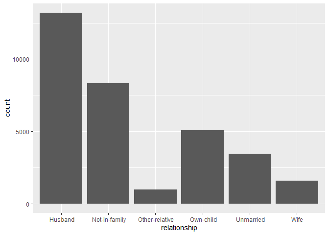

```r
# Bar plot of the relationship variable
ggplot(dataset, aes(x = relationship)) + geom_bar()
```

In ‘sex’ barplot, we see that the majority of the observations were Male.

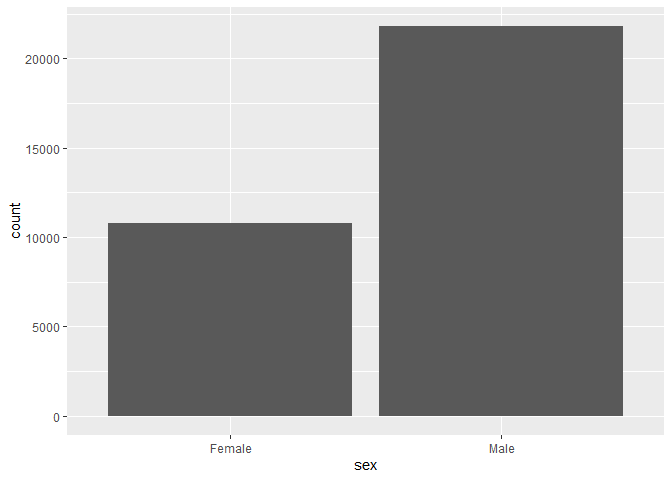

```r
# Bar plot of the sex variable
ggplot(dataset, aes(x = sex)) +geom_bar()
```

In the native.country bar plot, we can see that an astounding majority are from the United States.

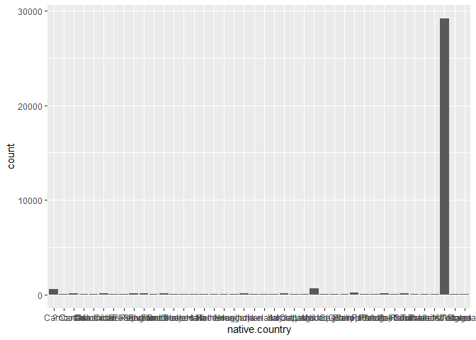

```r
# Bar plot of the native-country variable
ggplot(dataset, aes(x = native.country)) + geom_bar()
```

In the salary bar plot, we see that the majority of the rows are in the ‘<=50’ class. This tells us that the dataset is imbalanced. This is representative of real-world distribution.

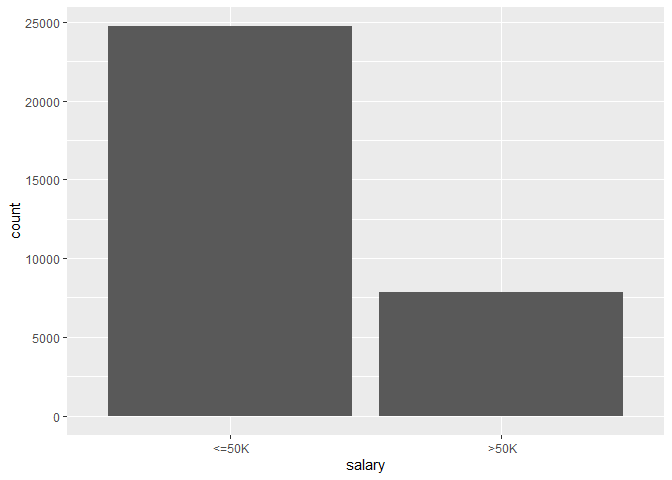

```r
# Bar plot of the salary variable
ggplot(dataset, aes(x = salary)) + geom_bar()
```

### Scatterplot

Scatterplots are plots that represent the relationship between variables.

The following scatterplot tells us that there’s no correlation between salary, hours.per.week, and age.

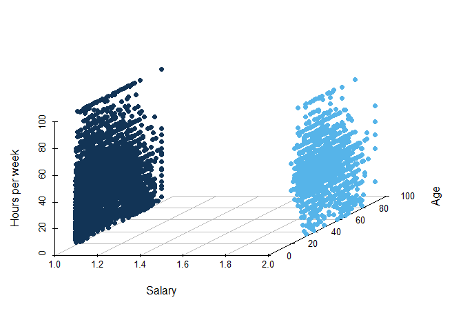

```r
grps <- as.factor(dataset$num_salary)
colors <- c("#123456", "#56B4E9", "#E69F00")
scatterplot3d(dataset$num_salary, dataset$age, dataset$hours.per.week, pch = 16, color = colors[grps],
              grid = TRUE, box = FALSE, xlab = "Salary",
              ylab = "Age", zlab = "Hours per week")
```

### Pie chart

Pie chart is a type of chart that represents data in a circular form, with every sector represents a portion of the data. What we can see in our pie-chart is that our dataset is unbalanced. With the majority of rows being classified under the ‘less than 50K’ class.

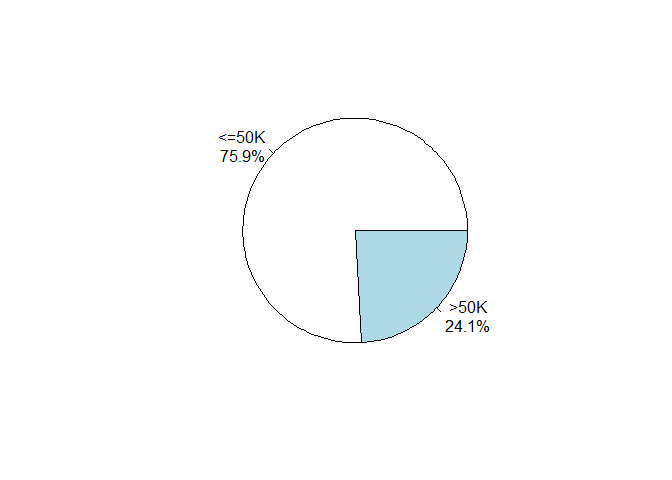

```r
tab <- dataset$salary %>% table()
precentages <- tab %>% prop.table() %>% round(3) * 100
txt <- paste0(names(tab), '\n', precentages, '%')
pie(tab, labels=txt)
```

### Create a density plot for the age variable

A density plot can be seen as an expansion of the histogram.It can smooth out the distribution of values and minimizes noise data. It peaks show where values are intensive.[3]

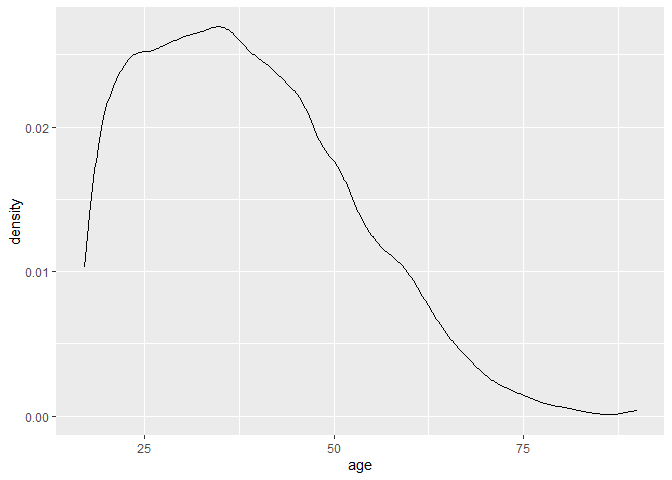

```r
ggplot(data = dataset, aes(x = age)) +
  geom_density()
```

# Data Preprocessing

First and foremost, we will remove a few of our columns. We will remove education, capital.gain, and capital.loss. Education to avoid redundancy, as we believe education.num is adequate on its own. We will remove capital.loss and capital.gain due to low variance, with overwhelming majority of rows being zero.

```r
dataset<- dataset[-c(4, 11,12)]
```

Here’s the dataset before preprocessing:

```r
head(dataset)
```

```
##   age         workclass fnlwgt education.num      marital.status
## 1  39         State-gov  77516            13       Never-married
## 2  50  Self-emp-not-inc  83311            13  Married-civ-spouse
## 3  38           Private 215646             9            Divorced
## 4  53           Private 234721             7  Married-civ-spouse
## 5  28           Private 338409            13  Married-civ-spouse
## 6  37           Private 284582            14  Married-civ-spouse
##           occupation   relationship   race     sex hours.per.week
## 1       Adm-clerical  Not-in-family  White    Male             40
## 2    Exec-managerial        Husband  White    Male             13
## 3  Handlers-cleaners  Not-in-family  White    Male             40
## 4  Handlers-cleaners        Husband  Black    Male             40
## 5     Prof-specialty           Wife  Black  Female             40
## 6    Exec-managerial           Wife  White  Female             40
##   native.country salary num_salary
## 1  United-States  <=50K          0
## 2  United-States  <=50K          0
## 3  United-States  <=50K          0
## 4  United-States  <=50K          0
## 5           Cuba  <=50K          0
## 6  United-States  <=50K          0
```

### Summary of the dataset

```r
summary(dataset)
```

```
##       age         workclass             fnlwgt        education.num
##  Min.   :17.00   Length:32561       Min.   :  12285   Min.   : 1.00
##  1st Qu.:28.00   Class :character   1st Qu.: 117827   1st Qu.: 9.00
##  Median :37.00   Mode  :character   Median : 178356   Median :10.00
##  Mean   :38.58                      Mean   : 189778   Mean   :10.08
##  3rd Qu.:48.00                      3rd Qu.: 237051   3rd Qu.:12.00
##  Max.   :90.00                      Max.   :1484705   Max.   :16.00
##  marital.status      occupation        relationship           race
##  Length:32561       Length:32561       Length:32561       Length:32561
##  Class :character   Class :character   Class :character   Class :character
##  Mode  :character   Mode  :character   Mode  :character   Mode  :character
##
##
##
##      sex            hours.per.week  native.country        salary
##  Length:32561       Min.   : 1.00   Length:32561       Length:32561
##  Class :character   1st Qu.:40.00   Class :character   Class :character
##  Mode  :character   Median :40.00   Mode  :character   Mode  :character
##                     Mean   :40.44
##                     3rd Qu.:45.00
##                     Max.   :99.00
##  num_salary
##  0:24720
##  1: 7841
##
##
##
##
```

## Data cleaning:

Before we start processing the data, we checked if our dataset contains missing or null values and delete them to maintain the efficiency of the data set.

### Removing missing values:

```r
dataset <- na.omit(dataset)
head(dataset)
```

```
##   age         workclass fnlwgt education.num      marital.status
## 1  39         State-gov  77516            13       Never-married
## 2  50  Self-emp-not-inc  83311            13  Married-civ-spouse
## 3  38           Private 215646             9            Divorced
## 4  53           Private 234721             7  Married-civ-spouse
## 5  28           Private 338409            13  Married-civ-spouse
## 6  37           Private 284582            14  Married-civ-spouse
##           occupation   relationship   race     sex hours.per.week
## 1       Adm-clerical  Not-in-family  White    Male             40
## 2    Exec-managerial        Husband  White    Male             13
## 3  Handlers-cleaners  Not-in-family  White    Male             40
## 4  Handlers-cleaners        Husband  Black    Male             40
## 5     Prof-specialty           Wife  Black  Female             40
## 6    Exec-managerial           Wife  White  Female             40
##   native.country salary num_salary
## 1  United-States  <=50K          0
## 2  United-States  <=50K          0
## 3  United-States  <=50K          0
## 4  United-States  <=50K          0
## 5           Cuba  <=50K          0
## 6  United-States  <=50K          0
```

### Removing outliers

We will detect outliers in all numerical attributes and remove them. The reason we do this is because outliers can affect the output of the result, leading to possible inaccuracy later on in the classification/clustering process.

```r
#Remove outlier
dataset= dataset[-Find_outlierHours,]

dataset= dataset[-Find_outlierFnlwgt,]

dataset= dataset[-Find_outlierAge,]
```

Printing the dataset after cleaning the data

```r
head(dataset)
```

```
##   age         workclass fnlwgt education.num      marital.status
## 1  39         State-gov  77516            13       Never-married
## 2  50  Self-emp-not-inc  83311            13  Married-civ-spouse
## 3  38           Private 215646             9            Divorced
## 4  53           Private 234721             7  Married-civ-spouse
## 5  28           Private 338409            13  Married-civ-spouse
## 6  37           Private 284582            14  Married-civ-spouse
##           occupation   relationship   race     sex hours.per.week
## 1       Adm-clerical  Not-in-family  White    Male             40
## 2    Exec-managerial        Husband  White    Male             13
## 3  Handlers-cleaners  Not-in-family  White    Male             40
## 4  Handlers-cleaners        Husband  Black    Male             40
## 5     Prof-specialty           Wife  Black  Female             40
## 6    Exec-managerial           Wife  White  Female             40
##   native.country salary num_salary
## 1  United-States  <=50K          0
## 2  United-States  <=50K          0
## 3  United-States  <=50K          0
## 4  United-States  <=50K          0
## 5           Cuba  <=50K          0
## 6  United-States  <=50K          0
```

## Data Transformation

### Encoding the data:

The reason we performed encoding on our dataset is because it not only preserves the integrity of our data, but also because machine learning algorithms work with numerical values.

A sample of the dataset before encoding:

```r
head(dataset)
```

```
##   age         workclass fnlwgt education.num      marital.status
## 1  39         State-gov  77516            13       Never-married
## 2  50  Self-emp-not-inc  83311            13  Married-civ-spouse
## 3  38           Private 215646             9            Divorced
## 4  53           Private 234721             7  Married-civ-spouse
## 5  28           Private 338409            13  Married-civ-spouse
## 6  37           Private 284582            14  Married-civ-spouse
##           occupation   relationship   race     sex hours.per.week
## 1       Adm-clerical  Not-in-family  White    Male             40
## 2    Exec-managerial        Husband  White    Male             13
## 3  Handlers-cleaners  Not-in-family  White    Male             40
## 4  Handlers-cleaners        Husband  Black    Male             40
## 5     Prof-specialty           Wife  Black  Female             40
## 6    Exec-managerial           Wife  White  Female             40
##   native.country salary num_salary
## 1  United-States  <=50K          0
## 2  United-States  <=50K          0
## 3  United-States  <=50K          0
## 4  United-States  <=50K          0
## 5           Cuba  <=50K          0
## 6  United-States  <=50K          0
```

We will know encode the dataset using the following code:

```r
dataset$workclass <-  as.integer(factor(dataset$workclass))
dataset$marital.status <-  as.integer(factor(dataset$marital.status))
dataset$occupation <-  as.integer(factor(dataset$occupation))
dataset$relationship <-  as.integer(factor(dataset$relationship))
dataset$race <-  as.integer(factor(dataset$race))
dataset$sex <-  as.integer(factor(dataset$sex))
dataset$native.country <-  as.integer(factor(dataset$native.country))
head(dataset)
```

```
##   age workclass fnlwgt education.num marital.status occupation relationship
## 1  39         8  77516            13              5          2            2
## 2  50         7  83311            13              3          5            1
## 3  38         5 215646             9              1          7            2
## 4  53         5 234721             7              3          7            1
## 5  28         5 338409            13              3         11            6
## 6  37         5 284582            14              3          5            6
##   race sex hours.per.week native.country salary num_salary
## 1    5   2             40             40  <=50K          0
## 2    5   2             13             40  <=50K          0
## 3    5   2             40             40  <=50K          0
## 4    3   2             40             40  <=50K          0
## 5    3   1             40              6  <=50K          0
## 6    5   1             40             40  <=50K          0
```

Sample of the dataset after encoding:

```r
head(dataset)
```

```
##   age workclass fnlwgt education.num marital.status occupation relationship
## 1  39         8  77516            13              5          2            2
## 2  50         7  83311            13              3          5            1
## 3  38         5 215646             9              1          7            2
## 4  53         5 234721             7              3          7            1
## 5  28         5 338409            13              3         11            6
## 6  37         5 284582            14              3          5            6
##   race sex hours.per.week native.country salary num_salary
## 1    5   2             40             40  <=50K          0
## 2    5   2             13             40  <=50K          0
## 3    5   2             40             40  <=50K          0
## 4    3   2             40             40  <=50K          0
## 5    3   1             40              6  <=50K          0
## 6    5   1             40             40  <=50K          0
```

### Normalization

Normalization is applied as part of data preparation for machine learning. Its purpose is to change the values of numeric columns in the dataset to use a common scale, without distorting differences in the ranges of values or losing information.

Sample of the dataset before normalization:

```r
head(dataset)
```

```
##   age workclass fnlwgt education.num marital.status occupation relationship
## 1  39         8  77516            13              5          2            2
## 2  50         7  83311            13              3          5            1
## 3  38         5 215646             9              1          7            2
## 4  53         5 234721             7              3          7            1
## 5  28         5 338409            13              3         11            6
## 6  37         5 284582            14              3          5            6
##   race sex hours.per.week native.country salary num_salary
## 1    5   2             40             40  <=50K          0
## 2    5   2             13             40  <=50K          0
## 3    5   2             40             40  <=50K          0
## 4    3   2             40             40  <=50K          0
## 5    3   1             40              6  <=50K          0
## 6    5   1             40             40  <=50K          0
```

Normalize attributes: age, fnlwgt, hours.per.week

```r
dataWithoutNormalization <- dataset

#Define function normalize().
normalize <- function(x) {return ((x - min(x)) / (max(x) - min(x)))}
#Define function Z_normalize().
Z_normalize <- function(x) {return ((x - mean(x)) / sd(x))}

#Call normalize function
dataset$age<-normalize(dataWithoutNormalization$age)


#Call Z_normalize function
dataset$age<-Z_normalize(dataWithoutNormalization$age)


######################################

#Call normalize function
dataset$fnlwgt<-normalize(dataWithoutNormalization$fnlwgt)


#Call Z_normalize function
dataset$fnlwgt<-Z_normalize(dataWithoutNormalization$fnlwgt)

######################################

#Call normalize function
dataset$hours.per.week<-normalize(dataWithoutNormalization$hours.per.week)


#Call Z_normalize function
dataset$hours.per.week<-Z_normalize(dataWithoutNormalization$hours.per.week)
```

Sample of the dataset after normalization:

```r
head(dataset)
```

```
##           age workclass     fnlwgt education.num marital.status occupation
## 1  0.03185481         8 -1.0642179            13              5          2
## 2  0.83846058         7 -1.0093300            13              3          5
## 3 -0.04147298         5  0.2440936             9              1          7
## 4  1.05844397         5  0.4247643             7              3          7
## 5 -0.77475095         5  1.4068551            13              3         11
## 6 -0.11480078         5  0.8970276            14              3          5
##   relationship race sex hours.per.week native.country salary num_salary
## 1            2    5   2     -0.0236719             40  <=50K          0
## 2            1    5   2     -2.2743379             40  <=50K          0
## 3            2    5   2     -0.0236719             40  <=50K          0
## 4            1    3   2     -0.0236719             40  <=50K          0
## 5            6    3   1     -0.0236719              6  <=50K          0
## 6            6    5   1     -0.0236719             40  <=50K          0
```

### Data summary after preprocessing:

```r
# number of rows
nrow(dataset)
```

```
## [1] 32432
```

There are 32432 rows in the dataset after preprocessing.

```r
# number of columns
ncol(dataset)
```

```
## [1] 13
```

There are 13 columns after preprocessing.

```r
# Dimensionalitly
 dim(dataset)
```

```
## [1] 32432    13
```

There are 32432 rows and 13 columns in the dataset after preprocessing

Here are the column Names of clean and transformed Dataset

```r
names(dataset)
```

```
##  [1] "age"            "workclass"      "fnlwgt"         "education.num"
##  [5] "marital.status" "occupation"     "relationship"   "race"
##  [9] "sex"            "hours.per.week" "native.country" "salary"
## [13] "num_salary"
```

Here’s the dataset after preprocessing:

```r
head(dataset)
```

```
##           age workclass     fnlwgt education.num marital.status occupation
## 1  0.03185481         8 -1.0642179            13              5          2
## 2  0.83846058         7 -1.0093300            13              3          5
## 3 -0.04147298         5  0.2440936             9              1          7
## 4  1.05844397         5  0.4247643             7              3          7
## 5 -0.77475095         5  1.4068551            13              3         11
## 6 -0.11480078         5  0.8970276            14              3          5
##   relationship race sex hours.per.week native.country salary num_salary
## 1            2    5   2     -0.0236719             40  <=50K          0
## 2            1    5   2     -2.2743379             40  <=50K          0
## 3            2    5   2     -0.0236719             40  <=50K          0
## 4            1    3   2     -0.0236719             40  <=50K          0
## 5            6    3   1     -0.0236719              6  <=50K          0
## 6            6    5   1     -0.0236719             40  <=50K          0
```

# Data Mining Techniques

Clustering and classification represent essential techniques in data mining, each serving distinct purposes. Clustering is unsupervised and focuses on grouping similar data points, while classification is supervised and involves training models to predict labels for new data. Both techniques contribute significantly to the exploration, analysis, and interpretation of large datasets, providing valuable insights and supporting decision-making processes in various domains.

## Clustering

First, we install the needed packages and libraries.

For clustering, we will be using the packages and libraries ‘dplyr’, ‘tidyverse’, ‘e1071’, ‘cluster’, ‘factoextra’, ‘fpc’.

The packages ‘dplyr’ and ‘tidyverse’ provide a set of functions for data manipulation and transformation. They are particularly useful for preparing and cleaning data before clustering.

The package ‘e1071’ includes functions for statistical learning, including support for the k-means clustering algorithm (kmeans). It is part of the core set of packages for machine learning and data analysis.

The ‘cluster’ package provides various clustering algorithms, such as hierarchical clustering and model-based clustering. It’s valuable for exploring different clustering methods.

The package ‘factoextra’ is designed for extracting and visualizing information from the results of multivariate data analyses. It complements clustering analyses by providing visualization functions to interpret and communicate the results.

Lastly, ‘fpc’, or Flexible Procedures for Clustering, package includes functions for assessing clustering tendency and quality. It provides metrics such as silhouette width (cluster.stats).

```r
install.packages("dplyr",  repos = "https://cran.r-project.org")
install.packages("tidyverse",  repos = "https://cran.r-project.org")
install.packages("e1071",  repos = "https://cran.r-project.org")
install.packages("cluster",  repos = "https://cran.r-project.org")
install.packages("factoextra",  repos = "https://cran.r-project.org")
install.packages("fpc",  repos = "https://cran.r-project.org")
library(dplyr)
library(tidyverse)
library(e1071)
library(cluster)
library(factoextra)
library(fpc)
```

Take a sample of the first 10,000 rows in the dataset.

```r
sampleDataset = dataset[1:10000,]
```

### Preparing the data before clustering:

We will first start by deleting the class label, as clustering is an unsupervised learning.

```r
data_clustring <- subset(sampleDataset, select = -c(salary, num_salary))
data_clustring <- scale(data_clustring[, sapply(data_clustring, is.numeric)])

head(data_clustring)
```

```
##           age  workclass     fnlwgt education.num marital.status occupation
## 1  0.04088688 2.13931300 -1.0647822     1.1493866      0.9183877 -1.3155864
## 2  0.84965455 1.45606654 -1.0102695     1.1493866     -0.4060826 -0.6127033
## 3 -0.03263745 0.08957361  0.2345843    -0.4227466     -1.7305528 -0.1441145
## 4  1.07022755 0.08957361  0.4140197    -1.2088132     -0.4060826 -0.1441145
## 5 -0.76788079 0.08957361  1.3893959     1.1493866     -0.4060826  0.7930631
## 6 -0.10616179 0.08957361  0.8830541     1.5424199     -0.4060826 -0.6127033
##   relationship       race        sex hours.per.week native.country
## 1   -0.2859678  0.3910899  0.7025686    -0.03519009      0.2956736
## 2   -0.9072316  0.3910899  0.7025686    -2.27606819      0.2956736
## 3   -0.2859678  0.3910899  0.7025686    -0.03519009      0.2956736
## 4   -0.9072316 -1.9698511  0.7025686    -0.03519009      0.2956736
## 5    2.1990877 -1.9698511 -1.4232063    -0.03519009     -3.9796105
## 6    2.1990877  0.3910899 -1.4232063    -0.03519009      0.2956736
```

It is a good idea to experiment with different values of k to determine the best value for our dataset. By using various methods, such as the silhouette coefficient or the gap statistic, to evaluate the quality of different clustering solutions and select the one that best represents the underlying structure of the data.

### Perform K-means clustering (for k = 2 clusters)

```r
kmeans_model <- kmeans(data_clustring,2 , nstart = 50)
sample(kmeans_model$cluster, 30)
```

```
## 2095 6748 3882 4544 7848  135 1450 1445 1866 8009 8520 3436 6324 9249 9597 5716
##    1    1    1    2    1    2    2    2    1    1    1    2    1    1    2    1
## 2436 4846 3787 1317 3282 6597  705 9349 1598 5370 1457  226 1054  238
##    1    2    2    2    2    2    2    2    1    2    2    1    2    2
```

#### Extract the cluster assignments

This stores cluster vector into a separate variable named clusters. This allows us to work with the cluster labels independently of the kmeans_model (we will use it for calculating the BCubed precision and recall)

```r
clusters <- kmeans_model$cluster
```

#### Visualize the clusters

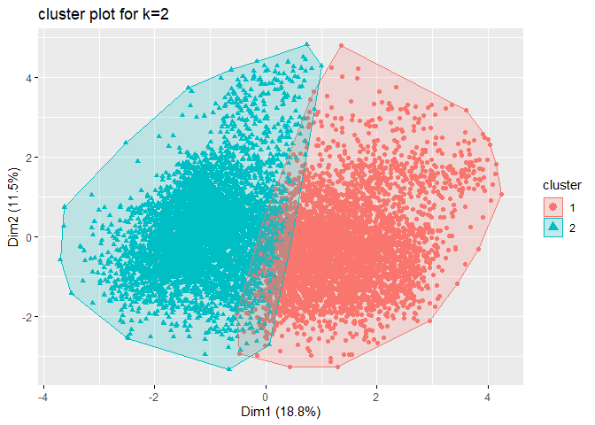

```r
fviz_cluster(list(data = data_clustring, cluster = clusters), geom = "point", main= "cluster plot for k=2")
```

**Plot Explanation:**

#### Calculating the avg silhouette

```
##   cluster size ave.sil.width
## 1       1 4276          0.09
## 2       2 5724          0.22
```

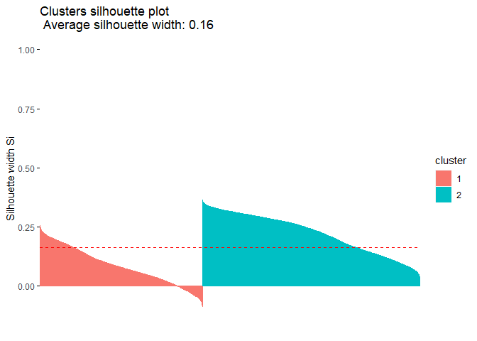

```r
avg_sil=silhouette (kmeans_model$cluster, dist(data_clustring))
fviz_silhouette(avg_sil)
```

#### Total within-cluster sum of square

The WCSS is a measure of the compactness of the clusters, and it represents the total distance of all data points within their respective clusters. A lower WCSS indicates that the clusters are more compact and well-separated, while a higher WCSS suggests that the clusters are more spread out and less distinct.

```r
kmeans_model$tot.withinss
```

```
## [1] 94215.99
```

Based on the graph and since the Total within-cluster sum of square is 94215.99, the clusters appear to be well-defined. The data points in each cluster are closely grouped together, and there is slight overlap between the two clusters. This suggests that the kmeans_model$tot.withinss value is relatively low, indicating that the clusters are compact.

#### Calculate BCubed precision and recall

First we set the ground truth

```r
ground_truth <- c(sampleDataset$salary)
```

#### Setting the functions for calculating the BCubed precision and recall

```r
BCubed_Precision <- function(clusters, ground_truth) {
  n <- length(clusters)
  precision <- 0
  for (i in 1:n) {
    same_cluster <- clusters == clusters[i]
    same_ground_truth <- ground_truth == ground_truth[i]
    precision <- precision + sum(same_cluster & same_ground_truth) / sum(same_cluster)
  }
  precision <- precision / n
  return(precision)
}

BCubed_Recall <- function(clusters, ground_truth) {
  n <- length(clusters)
  recall <- 0
  for (i in 1:n) {
    same_cluster <- clusters == clusters[i]
    same_ground_truth <- ground_truth == ground_truth[i]
    recall <- recall + sum(same_cluster & same_ground_truth) / sum(same_ground_truth)
  }
  recall <- recall / n
  return(recall)
}
```

#### Calculate BCubed precision and recall using the cluster assignments and ground truth

```r
precision <- BCubed_Precision(clusters, ground_truth)
recall <- BCubed_Recall(clusters, ground_truth)
```

#### View the calculated precision and recall

```r
print(precision)
```

```
## [1] 0.6728333
```

```r
print(recall)
```

```
## [1] 0.5575594
```

### Perform K-means clustering (for k = 3 clusters)

```r
kmeans_model <- kmeans(data_clustring,3 , nstart = 50)
sample(kmeans_model$cluster, 30)
```

```
## 8286 9551 6124 5473 3361 4777 8428 6269 8176 6052 2401 5705 5516 3734 8997 3687
##    2    2    1    1    1    2    1    1    2    2    1    1    1    1    1    1
## 1453 1326 7599 8336 1238 4119 9592 2861 4378 5545 2949 1927 2117 1498
##    1    1    1    2    3    2    1    2    2    2    2    2    2    2
```

#### Extract the cluster assignments

This stores cluster vector into a separate variable named clusters. This allows us to work with the cluster labels independently of the kmeans_model (we will use it for calculating the BCubed precision and recall)

```r
clusters <- kmeans_model$cluster
```

#### Visualize the clusters

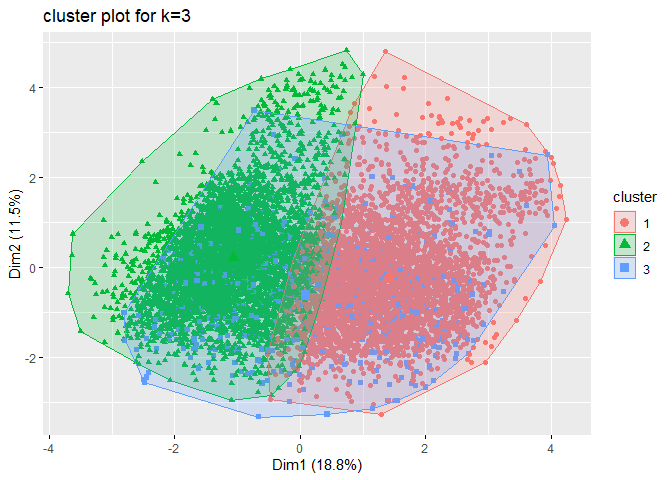

```r
fviz_cluster(list(data = data_clustring, cluster = clusters), geom = "point", main= "cluster plot for k=3")
```

**Plot Explanation:**

The cluster plot effectively identifies three distinct groups of data points. The clusters overlap between the blue cluster and the red and green clusters.

#### Calculating the avg silhouette

```
##   cluster size ave.sil.width
## 1       1 4018          0.09
## 2       2 5404          0.24
## 3       3  578          0.18
```

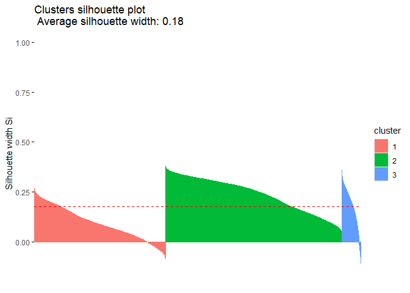

```r
avg_sil=silhouette (kmeans_model$cluster, dist(data_clustring))
fviz_silhouette(avg_sil)
```

**Plot Explanation:**

The plot shows silhouette width of 0.18 it is considered to be a low, but it is not necessarily bad. It simply means that the clusters are not perfectly separated(maybe due to the clusters overlapping) .

#### Total within-cluster sum of square

```r
kmeans_model$tot.withinss
```

```
## [1] 86246.29
```

The kmeans_model$tot.withinss value of 86246.29 indicates that the clusters are compact. The data points in each cluster are tightly grouped together.

#### Calculate BCubed precision and recall

First we set the ground truth

```r
ground_truth <- c(sampleDataset$salary)
```

#### Setting the functions for calculating the BCubed precision and recall

```r
BCubed_Precision <- function(clusters, ground_truth) {
  n <- length(clusters)
  precision <- 0
  for (i in 1:n) {
    same_cluster <- clusters == clusters[i]
    same_ground_truth <- ground_truth == ground_truth[i]
    precision <- precision + sum(same_cluster & same_ground_truth) / sum(same_cluster)
  }
  precision <- precision / n
  return(precision)
}

BCubed_Recall <- function(clusters, ground_truth) {
  n <- length(clusters)
  recall <- 0
  for (i in 1:n) {
    same_cluster <- clusters == clusters[i]
    same_ground_truth <- ground_truth == ground_truth[i]
    recall <- recall + sum(same_cluster & same_ground_truth) / sum(same_ground_truth)
  }
  recall <- recall / n
  return(recall)
}
```

#### Calculate BCubed precision and recall using the cluster assignments and ground truth

```r
precision <- BCubed_Precision(clusters, ground_truth)
recall <- BCubed_Recall(clusters, ground_truth)
```

#### View the calculated precision and recall

```r
print(precision)
```

```
## [1] 0.670029
```

```r
print(recall)
```

```
## [1] 0.4975389
```

### Perform K-means clustering (for k = 4 clusters)

```r
kmeans_model <- kmeans(data_clustring,4 , nstart = 50)
sample(kmeans_model$cluster, 30)
```

```
##  9127   479  2781  6547  8963  7299  3570  4059  6610  2029  3564  6428  7780
##     3     2     3     3     4     2     2     3     3     3     3     2     2
##  1531   985  4731  8465  4849  4269  5687  2336   738  3467  5731  9275  8765
##     3     2     4     4     2     3     2     2     3     3     3     3     3
## 10027  5657  3732  9727
##     2     2     3     2
```

#### Extract the cluster assignments

This stores cluster vector into a separate variable named clusters. This allows us to work with the cluster labels independently of the kmeans_model (we will use it for calculating the BCubed precision and recall)

```r
clusters <- kmeans_model$cluster
```

#### Visualize the clusters

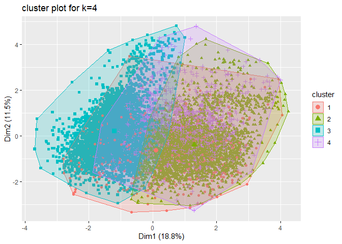

```r
fviz_cluster(list(data = data_clustring, cluster = clusters), geom = "point", main= "cluster plot for k=4")
```

#### Calculating the avg silhouette

```
##   cluster size ave.sil.width
## 1       1  571          0.17
## 2       2 3298          0.10
## 3       3 4677          0.23
## 4       4 1454          0.15
```

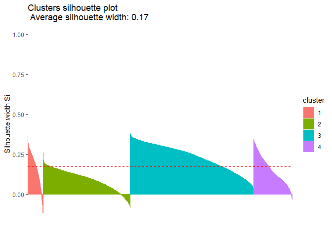

```r
avg_sil=silhouette (kmeans_model$cluster, dist(data_clustring))
fviz_silhouette(avg_sil)
```

**Plot Explanation:**

The plot shows silhouette width of 0.17 it is considered to be a low, but it is not necessarily bad. It simply means that the clusters are not perfectly separated (maybe due to the overlapping) .

#### Total within-cluster sum of square

```r
kmeans_model$tot.withinss
```

```
## [1] 79699.02
```

#### Calculate BCubed precision and recall

First we set the ground truth

```r
ground_truth <- c(sampleDataset$salary)
```

#### Setting the functions for calculating the BCubed precision and recall

```r
BCubed_Precision <- function(clusters, ground_truth) {
  n <- length(clusters)
  precision <- 0
  for (i in 1:n) {
    same_cluster <- clusters == clusters[i]
    same_ground_truth <- ground_truth == ground_truth[i]
    precision <- precision + sum(same_cluster & same_ground_truth) / sum(same_cluster)
  }
  precision <- precision / n
  return(precision)
}

BCubed_Recall <- function(clusters, ground_truth) {
  n <- length(clusters)
  recall <- 0
  for (i in 1:n) {
    same_cluster <- clusters == clusters[i]
    same_ground_truth <- ground_truth == ground_truth[i]
    recall <- recall + sum(same_cluster & same_ground_truth) / sum(same_ground_truth)
  }
  recall <- recall / n
  return(recall)
}
```

#### Calculate BCubed precision and recall using the cluster assignments and ground truth

```r
precision <- BCubed_Precision(clusters, ground_truth)
recall <- BCubed_Recall(clusters, ground_truth)
```

#### View the calculated precision and recall

```r
print(precision)
```

```
## [1] 0.6884835
```

```r
print(recall)
```

```
## [1] 0.4061215
```

### Evaluation and Comparison: Clustering

[output not shown]

#### Analysis:

Average Silhouette Width: K=3 shows the highest silhouette width (0.18), indicating better-defined clusters in comparison to K=2 and K=4.

Total Within-Cluster Sum of Squares: As the number of clusters increases, the total within-cluster sum of squares decreases, suggesting better compactness or tighter clustering.

Precision and Recall: While precision remains relatively consistent, recall shows a decline as the number of clusters increases. This suggests a trade-off between precision and recall, where a higher number of clusters might lead to better precision but lower recall due to more fragmented or smaller clusters.

**Overall Comparison:**

K=2 has the highest recall, highlighting the ability to find all relevant cases.

K=3 appears to strike a balance with good silhouette width and reasonable precision and recall. It shows the highest average silhouette width, indicating well-defined clusters.

K=4 shows high precision but at the expense of lower recall, possibly due to the fragmentation of data into smaller clusters. It demonstrates the lowest total within-cluster sum of square, suggesting more compact clusters.

**Comparison of WCSS:**

Clustering Result 1: kmeans_model$tot.withinss = 94215.99

The clusters appear to be well-defined in the graph. The WCSS value of 94215.99 is moderate, suggesting that the clusters are neither overly compact nor overly spread out.

Clustering Result 2: kmeans_model$tot.withinss = 86246.29

The clusters appear to be compact in the graph. The WCSS value of 86246.29 is lower than the first clustering result, indicating that the clusters are more compact in this case.

Clustering Result 3: kmeans_model$tot.withinss = 79699.02

The clusters appear to be very compact in the graph. The WCSS value of 79699.02 is the lowest of the three clustering results, indicating that the clusters are the most compact in this case.

### Finding optimal number of clusters

```r
silhouette_score <- function(k){
km <- kmeans(data_clustring, centers = k,nstart=50) # if centers is a number, how many random sets should be chosen?
ss <- silhouette(km$cluster, dist(data_clustring))
sil<- mean(ss[, 3])
return(sil)
}
```

#### k cluster range from 2 to 10

```r
k <- 2:10
```

#### call function fore k value

```r
avg_sil <- sapply(k, silhouette_score)
```

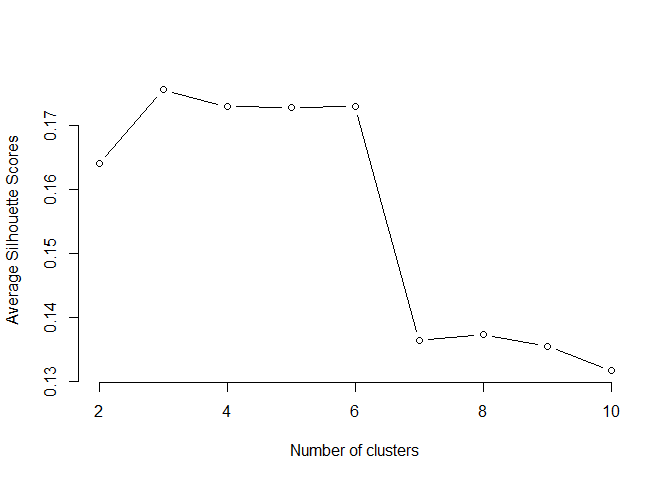

```r
plot(k, type='b', avg_sil, xlab='Number of clusters', ylab='Average Silhouette Scores', frame=FALSE)
```

The Silhouette method graph shows how the average silhouette coefficient changes as the number of clusters (k) increases. The optimal number of clusters is often chosen as the value of k that corresponds to the highest average silhouette coefficient. However, it is important to note that the highest average silhouette coefficient may not necessarily indicate the best clustering solution. For example, if the average silhouette coefficient is high for all values of k, it may suggest that the data is not well-clustered at all.

### Finding the optimal number of clusters applying Silhouette method

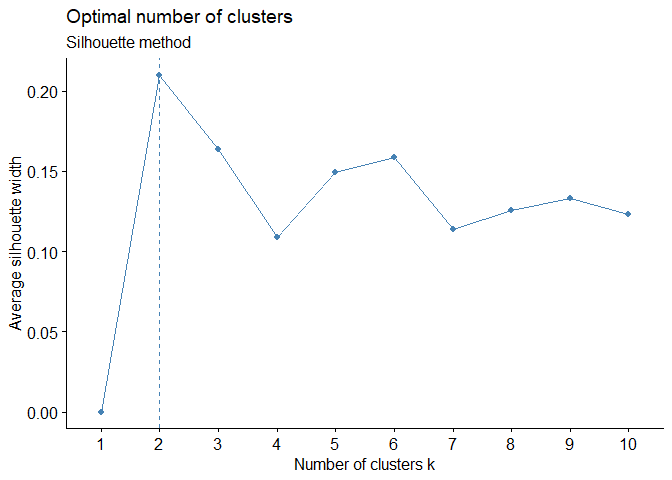

```r
fviz_nbclust(data_clustring, kmeans, method = "silhouette")+
  labs(subtitle = "Silhouette method")
```

### Finding the optimal number of clusters applying Elbow method

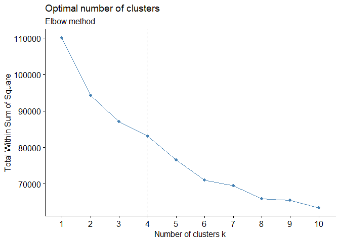

```r
fviz_nbclust(data_clustring, kmeans, method = "wss") +
  geom_vline(xintercept = 4, linetype = 2)+
  labs(subtitle = "Elbow method")
```

## Classification

Classification uses supervised learning, meaning it uses labeled datasets to train models to classify or predict data. We will be applying three different algorithms: ID3, C4.5, and CART.

First, we’ll start with installing the neccessary libraries and packages.

```r
install.packages("party",  repos = "https://cran.r-project.org")
library(party)
install.packages("caret",  repos = "https://cran.r-project.org")
library(caret)
install.packages("ctree",  repos = "https://cran.r-project.org")
library(rpart)
```

```r
library(rpart.plot)
library(RWeka)
install.packages("partykit",  repos = "https://cran.r-project.org")
```

### ID3 Algorithm:

In the ID3 trees, we will be using the packages ‘party’, ‘caret’, and the library ‘ctree’.

The ‘party’ package provides functionalities for recursive partitioning and constructing decision trees. And the ‘caret’ package acts as a unified interface to various machine learning algorithms and provides tools for preprocessing, feature selection, model training, and evaluation. The ‘ctree’ library is specifically designed for constructing conditional inference trees.

Taking a sample of the first 10000 rows in our dataset, we then divided them into two: a training set and a testing set. For the training model, we used 3 different sizes; 60%, 70% and 80%.

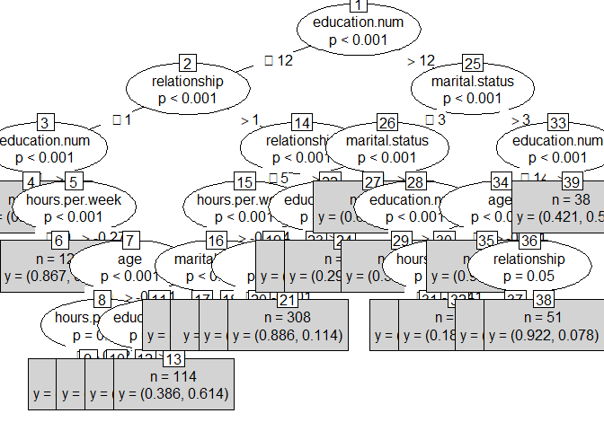

```r
#evaluation: 60% training, 40% testing

sampleDataset=dataset[1:10000, ]
set.seed(1234)
ind <- sample(2, nrow(sampleDataset), replace = TRUE, prob = c(0.6, 0.4))
trainingData <- sampleDataset[ind == 1,]
testingData <- sampleDataset[ind == 2,]

myFormula <- num_salary ~ age + workclass + fnlwgt +education.num +marital.status + hours.per.week + occupation + relationship + race + sex  + native.country
salary_Tree <- ctree(myFormula, data = trainingData)
plot(salary_Tree, type = "simple")
```

```r
print(salary_Tree)
```

```
##
##   Conditional inference tree with 20 terminal nodes
##
## Response:  num_salary
## Inputs:  age, workclass, fnlwgt, education.num, marital.status, hours.per.week, occupation, relationship, race, sex, native.country
## Number of observations:  6011
##
## 1) education.num <= 12; criterion = 1, statistic = 641.407
##   2) relationship <= 1; criterion = 1, statistic = 184.121
##     3) education.num <= 8; criterion = 1, statistic = 69.316
##       4)*  weights = 285
##     3) education.num > 8
##       5) hours.per.week <= -0.2737459; criterion = 1, statistic = 28.706
##         6)*  weights = 128
##       5) hours.per.week > -0.2737459
##         7) age <= -0.2614564; criterion = 1, statistic = 28.679
##           8) hours.per.week <= 0.7265501; criterion = 0.999, statistic = 15.037
##             9)*  weights = 284
##           8) hours.per.week > 0.7265501
##             10)*  weights = 128
##         7) age > -0.2614564
##           11) education.num <= 10; criterion = 0.998, statistic = 14.036
##             12)*  weights = 756
##           11) education.num > 10
##             13)*  weights = 114
##   2) relationship > 1
##     14) relationship <= 5; criterion = 1, statistic = 105.723
##       15) hours.per.week <= -0.0236719; criterion = 1, statistic = 33.562
##         16) marital.status <= 4; criterion = 1, statistic = 22.281
##           17)*  weights = 566
##         16) marital.status > 4
##           18)*  weights = 1559
##       15) hours.per.week > -0.0236719
##         19) age <= -0.7014232; criterion = 0.99, statistic = 10.924
##           20)*  weights = 172
##         19) age > -0.7014232
##           21)*  weights = 308
##     14) relationship > 5
##       22) education.num <= 11; criterion = 0.998, statistic = 14.183
##         23)*  weights = 203
```

[output cut: 10 more lines]

```
##         30) hours.per.week <= -1.940906; criterion = 0.997, statistic = 13.323
##           31)*  weights = 13
##         30) hours.per.week > -1.940906
##           32)*  weights = 294
##   25) marital.status > 3
##     33) education.num <= 14; criterion = 1, statistic = 56.71
##       34) age <= -0.4814398; criterion = 1, statistic = 31.916
##         35)*  weights = 274
##       34) age > -0.4814398
##         36) relationship <= 2; criterion = 0.95, statistic = 8.02
##           37)*  weights = 163
##         36) relationship > 2
##           38)*  weights = 51
##     33) education.num > 14
##       39)*  weights = 38
```

**Tree Explanation:** Root Splitting Criteria: The tree begins by splitting the data based on the education level (education.num). This means the algorithm is trying to find patterns related to education.

Low Education Level (education.num <= 12):

```r
# Convert the response variable to a factor
testingData$num_salary <- as.factor(testingData$num_salary)

# Data Prediction
testPrediction <- predict(salary_Tree, newdata = testingData)

# Ensure testPrediction has the same levels as testingData$num_salary
testPrediction <- factor(testPrediction, levels = levels(testingData$num_salary))

# Create Confusion Matrix
results <- confusionMatrix(as.factor(testPrediction), testingData$num_salary)
print(results)
```

```
## Confusion Matrix and Statistics
##
##           Reference
## Prediction    0    1
##          0 2870  500
##          1  207  412
##
##                Accuracy : 0.8228
##                  95% CI : (0.8106, 0.8345)
##     No Information Rate : 0.7714
##     P-Value [Acc > NIR] : 1.05e-15
##
##                   Kappa : 0.4335
##
##  Mcnemar's Test P-Value : < 2.2e-16
##
##             Sensitivity : 0.9327
##             Specificity : 0.4518
##          Pos Pred Value : 0.8516
##          Neg Pred Value : 0.6656
##              Prevalence : 0.7714
##          Detection Rate : 0.7195
##    Detection Prevalence : 0.8448
##       Balanced Accuracy : 0.6922
##
##        'Positive' Class : 0
##
```

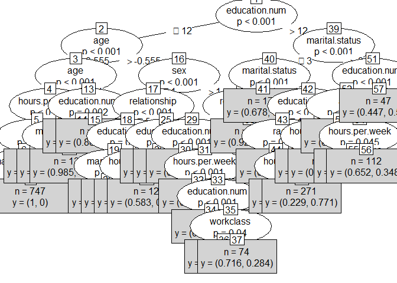

```r
#evaluation: 70% training, 30% testing

sampleDataset=dataset[1:10000, ]
set.seed(1234)
ind <- sample(2, nrow(sampleDataset), replace = TRUE, prob = c(0.7, 0.3))
trainingData <- sampleDataset[ind == 1,]
testingData <- sampleDataset[ind == 2,]

myFormula <- num_salary ~ age + workclass + fnlwgt +education.num +marital.status + hours.per.week + occupation + relationship + race + sex  + native.country
salary_Tree <- ctree(myFormula, data = trainingData)

plot(salary_Tree, type = "simple")
```

```r
print(salary_Tree)
```

```
##
##   Conditional inference tree with 29 terminal nodes
##
## Response:  num_salary
## Inputs:  age, workclass, fnlwgt, education.num, marital.status, hours.per.week, occupation, relationship, race, sex, native.country
## Number of observations:  7041
##
## 1) education.num <= 12; criterion = 1, statistic = 770.929
##   2) age <= -0.5547676; criterion = 1, statistic = 208.53
##     3) age <= -0.9214065; criterion = 1, statistic = 86.742
##       4) hours.per.week <= 0.0596861; criterion = 1, statistic = 34.627
##         5) age <= -1.214718; criterion = 0.995, statistic = 12.28
##           6) native.country <= 7; criterion = 1, statistic = 25.872
##             7)*  weights = 12
##           6) native.country > 7
##             8)*  weights = 747
##         5) age > -1.214718
##           9)*  weights = 416
##       4) hours.per.week > 0.0596861
##         10) marital.status <= 3; criterion = 0.986, statistic = 10.361
##           11)*  weights = 67
##         10) marital.status > 3
##           12)*  weights = 131
##     3) age > -0.9214065
##       13) education.num <= 8; criterion = 0.998, statistic = 13.599
##         14)*  weights = 95
##       13) education.num > 8
##         15)*  weights = 588
##   2) age > -0.5547676
##     16) sex <= 1; criterion = 1, statistic = 96.851
##       17) relationship <= 5; criterion = 1, statistic = 88.785
##         18) education.num <= 10; criterion = 0.99, statistic = 11.007
##           19) marital.status <= 4; criterion = 0.987, statistic = 10.567
##             20)*  weights = 357
##           19) marital.status > 4
##             21)*  weights = 358
##         18) education.num > 10
##           22) hours.per.week <= 0.5598341; criterion = 0.962, statistic = 8.537
##             23)*  weights = 83
##           22) hours.per.week > 0.5598341
```

[output cut: 37 more lines]

```
##         48) hours.per.week <= -1.940906; criterion = 0.987, statistic = 10.543
##           49)*  weights = 14
##         48) hours.per.week > -1.940906
##           50)*  weights = 345
##   39) marital.status > 3
##     51) education.num <= 14; criterion = 1, statistic = 65.531
##       52) age <= -0.7014232; criterion = 1, statistic = 35.789
##         53)*  weights = 259
##       52) age > -0.7014232
##         54) hours.per.week <= 0.1430441; criterion = 0.955, statistic = 8.215
##           55)*  weights = 191
##         54) hours.per.week > 0.1430441
##           56)*  weights = 112
##     51) education.num > 14
##       57)*  weights = 47
```

**Tree Explanation:**

Root Splitting Criteria: this tree starts by splitting based on education level (education.num).

Low Education Level (education.num <= 12):

It considers conditions related to age, hours worked per week, marital status, and native country.

For example, if a person’s age is below a certain threshold and their native country is above a certain value, it predicts a certain income level.

If a person has a higher education level (education.num > 12), the tree looks at conditions related to age, sex, relationship status, and education level to make predictions.

```r
# Convert the response variable to a factor
testingData$num_salary <- as.factor(testingData$num_salary)

# Data Prediction
testPrediction <- predict(salary_Tree, newdata = testingData)

# Ensure testPrediction has the same levels as testingData$num_salary
testPrediction <- factor(testPrediction, levels = levels(testingData$num_salary))

# Create Confusion Matrix
results <- confusionMatrix(as.factor(testPrediction), testingData$num_salary)
print(results)
```

```
## Confusion Matrix and Statistics
##
##           Reference
## Prediction    0    1
##          0 2084  304
##          1  203  368
##
##                Accuracy : 0.8287
##                  95% CI : (0.8146, 0.8421)
##     No Information Rate : 0.7729
##     P-Value [Acc > NIR] : 4.624e-14
##
##                   Kappa : 0.4846
##
##  Mcnemar's Test P-Value : 8.948e-06
##
##             Sensitivity : 0.9112
##             Specificity : 0.5476
##          Pos Pred Value : 0.8727
##          Neg Pred Value : 0.6445
##              Prevalence : 0.7729
##          Detection Rate : 0.7043
##    Detection Prevalence : 0.8070
##       Balanced Accuracy : 0.7294
##
##        'Positive' Class : 0
##
```

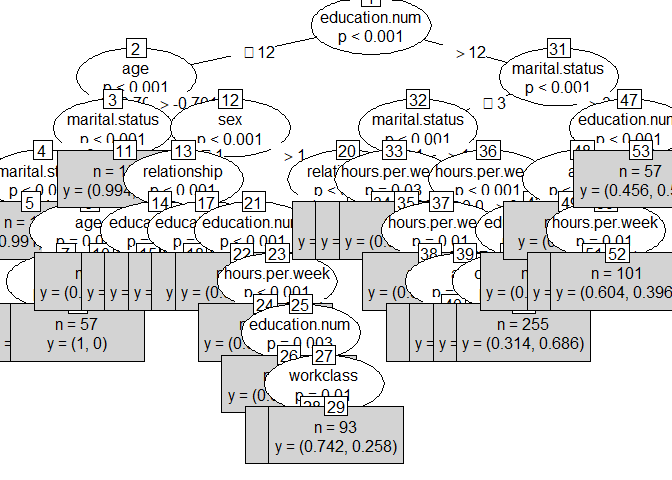

```r
##evaluation: 80% training, 20% testing
sampleDataset=dataset[1:10000, ]
set.seed(1234)
ind <- sample(2, nrow(sampleDataset), replace = TRUE, prob = c(0.8, 0.2))
trainingData <- sampleDataset[ind == 1,]
testingData <- sampleDataset[ind == 2,]

myFormula <- num_salary ~ age + workclass + fnlwgt +education.num +marital.status + hours.per.week + occupation + relationship + race + sex + native.country
salary_Tree <- ctree(myFormula, data = trainingData)

plot(salary_Tree, type = "simple")
```

```r
print(salary_Tree)
```

```
##
##   Conditional inference tree with 27 terminal nodes
##
## Response:  num_salary
## Inputs:  age, workclass, fnlwgt, education.num, marital.status, hours.per.week, occupation, relationship, race, sex, native.country
## Number of observations:  8014
##
## 1) education.num <= 12; criterion = 1, statistic = 879.807
##   2) age <= -0.7014232; criterion = 1, statistic = 248.18
##     3) marital.status <= 3; criterion = 1, statistic = 58.453
##       4) marital.status <= 2; criterion = 0.999, statistic = 15.422
##         5)*  weights = 115
##       4) marital.status > 2
##         6) age <= -1.14139; criterion = 0.982, statistic = 9.878
##           7) race <= 3; criterion = 1, statistic = 16.99
##             8)*  weights = 8
##           7) race > 3
##             9)*  weights = 57
##         6) age > -1.14139
##           10)*  weights = 290
##     3) marital.status > 3
##       11)*  weights = 1545
##   2) age > -0.7014232
##     12) sex <= 1; criterion = 1, statistic = 124.682
##       13) relationship <= 5; criterion = 1, statistic = 96.411
##         14) education.num <= 10; criterion = 0.996, statistic = 12.814
##           15)*  weights = 907
##         14) education.num > 10
##           16)*  weights = 125
##       13) relationship > 5
##         17) education.num <= 11; criterion = 0.999, statistic = 15.23
##           18)*  weights = 216
##         17) education.num > 11
##           19)*  weights = 20
##     12) sex > 1
##       20) relationship <= 1; criterion = 1, statistic = 145.12
##         21) education.num <= 8; criterion = 1, statistic = 84.907
##           22)*  weights = 321
##         21) education.num > 8
##           23) hours.per.week <= -0.5238199; criterion = 1, statistic = 27.599
```

[output cut: 31 more lines]

```
##           43) occupation > 5
##             45)*  weights = 255
##         42) education.num > 14
##           46)*  weights = 103
##   31) marital.status > 3
##     47) education.num <= 14; criterion = 1, statistic = 71.524
##       48) age <= -0.4814398; criterion = 1, statistic = 46.45
##         49)*  weights = 363
##       48) age > -0.4814398
##         50) hours.per.week <= 0.3097601; criterion = 0.99, statistic = 11.081
##           51)*  weights = 183
##         50) hours.per.week > 0.3097601
##           52)*  weights = 101
##     47) education.num > 14
##       53)*  weights = 57
```

**Tree Explanation:**

Root Splitting Criteria: The third decision tree begins by splitting based on education level (education.num).

Low Education Level (education.num <= 12):

If a person has a low education level, the tree considers their age and marital status to make predictions.

It looks at conditions related to these features and reaches terminal nodes with specific predictions.

It further branches based on these conditions until reaching terminal nodes with predictions.

```r
# Convert the response variable to a factor
testingData$num_salary <- as.factor(testingData$num_salary)

# Data Prediction
testPrediction <- predict(salary_Tree, newdata = testingData)

# Ensure testPrediction has the same levels as testingData$num_salary
testPrediction <- factor(testPrediction, levels = levels(testingData$num_salary))

# Create Confusion Matrix
results <- confusionMatrix(as.factor(testPrediction), testingData$num_salary)
print(results)
```

```
## Confusion Matrix and Statistics
##
##           Reference
## Prediction    0    1
##          0 1466  290
##          1   62  168
##
##                Accuracy : 0.8228
##                  95% CI : (0.8052, 0.8393)
##     No Information Rate : 0.7694
##     P-Value [Acc > NIR] : 3.6e-09
##
##                   Kappa : 0.3951
##
##  Mcnemar's Test P-Value : < 2e-16
##
##             Sensitivity : 0.9594
##             Specificity : 0.3668
##          Pos Pred Value : 0.8349
##          Neg Pred Value : 0.7304
##              Prevalence : 0.7694
##          Detection Rate : 0.7382
##    Detection Prevalence : 0.8842
##       Balanced Accuracy : 0.6631
##
##        'Positive' Class : 0
##
```

**Summary:** The algorithm shows varying degrees of accuracy, sensitivity, specificity, and precision, suggesting its performance is influenced by the composition of the training and testing datasets.

After constructing our three decision trees using ID3 algorithm, we can see that the attribute ‘education.num’ was the root node in all three of our trees. This means that ‘education.num’ has the highest information gain.

### CART Algorithm

We will be using the libraries ‘rpart’ and ‘rpart.plot’. The ‘rpart’ package allows users to build decision trees based on recursive binary splits, creating a tree structure that best separates the data based on predictor variables.

And the ‘rpart.plot’ package complements the ‘rpart’ package by providing functions to visualize decision trees created using ‘rpart’.

Let’s first start with cp=0.1.

```r
over50K=ifelse(dataset$num_salary==1, "Yes", "No")
dataset<-data.frame(dataset, over50K)
```

```r
#Remove salary, num_salary

dataset.salary <- subset(dataset, select = -c(salary, num_salary))

head(dataset.salary)
```

```
##           age workclass     fnlwgt education.num marital.status occupation
## 1  0.03185481         8 -1.0642179            13              5          2
## 2  0.83846058         7 -1.0093300            13              3          5
## 3 -0.04147298         5  0.2440936             9              1          7
## 4  1.05844397         5  0.4247643             7              3          7
## 5 -0.77475095         5  1.4068551            13              3         11
## 6 -0.11480078         5  0.8970276            14              3          5
##   relationship race sex hours.per.week native.country over50K
## 1            2    5   2     -0.0236719             40      No
## 2            1    5   2     -2.2743379             40      No
## 3            2    5   2     -0.0236719             40      No
## 4            1    3   2     -0.0236719             40      No
## 5            6    3   1     -0.0236719              6      No
## 6            6    5   1     -0.0236719             40      No
```

```r
dataset.salary$over50K = as.factor(dataset$over50K)
class(dataset.salary$over50K)
```

```
## [1] "factor"
```

```r
set.seed(1234)
train = seq_len(10000)
dataset.train=dataset.salary[train,]
dataset.test=dataset.salary[-train,]

over50K.test=over50K[-train]

#CP=0.1

fit.tree = rpart(over50K ~ ., data=dataset.train, method = "class", cp=0.1)
fit.tree
```

```
## n= 10000
##
## node), split, n, loss, yval, (yprob)
##       * denotes terminal node
##
## 1) root 10000 2373 No (0.76270000 0.23730000)
##   2) relationship>=1.5 6010  600 No (0.90016639 0.09983361) *
##   3) relationship< 1.5 3990 1773 No (0.55563910 0.44436090)
##     6) education.num< 12.5 2790  923 No (0.66917563 0.33082437) *
##     7) education.num>=12.5 1200  350 Yes (0.29166667 0.70833333) *
```

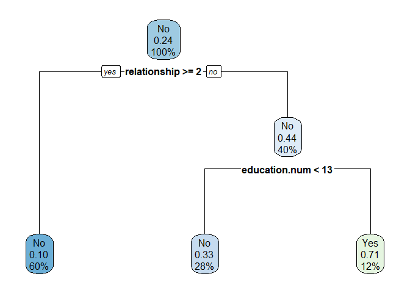

```r
rpart.plot(fit.tree)
```

```r
# Checking the order of variable importance
fit.tree$variable.importance
```

```
##   relationship marital.status  education.num            sex            age
##      569.27829      291.48761      239.16470      183.05365       56.26886
## hours.per.week      workclass
##       55.64374       35.15277
```

```r
pred.tree = predict(fit.tree, dataset.test, type = "class")
confMatBeforePruning=table(pred.tree,over50K.test)
#plotcp(fit.tree)
printcp(fit.tree)
```

```
##
## Classification tree:
## rpart(formula = over50K ~ ., data = dataset.train, method = "class",
##     cp = 0.1)
##
## Variables actually used in tree construction:
## [1] education.num relationship
##
## Root node error: 2373/10000 = 0.2373
##
## n= 10000
##
##        CP nsplit rel error  xerror     xstd
## 1 0.10535      0    1.0000 1.00000 0.017928
## 2 0.10000      2    0.7893 0.79351 0.016475
```

```r
#calculate accuracy:
accuracy <- sum(diag(confMatBeforePruning))/sum(confMatBeforePruning)
accuracy
```

```
## [1] 0.8143723
```

```r
#calculate sensitivity:
tp <- confMatBeforePruning[2, 2]
fn <- confMatBeforePruning[2, 1]
sensitivity <- tp / (tp + fn)
sensitivity
```

```
## [1] 0.7307832
```

```r
#calculate specificity:
tn <- confMatBeforePruning[1, 1]
fp <- confMatBeforePruning[1, 2]

specificity <- tn / (tn + fp)
specificity
```

```
## [1] 0.8260273
```

```r
#calculate precision:
tp <- confMatBeforePruning[2, 2]
fp <- confMatBeforePruning[1, 2]

precision <- tp / (tp + fp)
precision
```

```
## [1] 0.3693611
```

```r
# Explicitly request the lowest cp value
fit.tree$cptable[which.min(fit.tree$cptable[,"xerror"]),"CP"]
```

```
## [1] 0.1
```

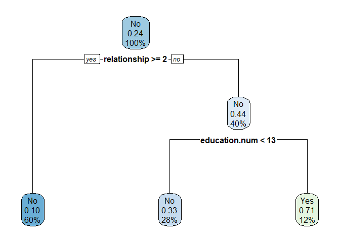

```r
bestcp <-fit.tree$cptable[which.min(fit.tree$cptable[,"xerror"]),"CP"]
pruned.tree <- prune(fit.tree, cp = bestcp)
rpart.plot(pruned.tree)
```

```r
pruned.tree
```

```
## n= 10000
##
## node), split, n, loss, yval, (yprob)
##       * denotes terminal node
##
## 1) root 10000 2373 No (0.76270000 0.23730000)
##   2) relationship>=1.5 6010  600 No (0.90016639 0.09983361) *
##   3) relationship< 1.5 3990 1773 No (0.55563910 0.44436090)
##     6) education.num< 12.5 2790  923 No (0.66917563 0.33082437) *
##     7) education.num>=12.5 1200  350 Yes (0.29166667 0.70833333) *
```

```r
# Alternate specification
pred.prune = predict(pruned.tree, dataset.test, type="class")
confMatAfterPruning=table(pred.prune, over50K.test)

#calculate accuracy:
accuracy <- sum(diag(confMatAfterPruning))/sum(confMatAfterPruning)
accuracy
```

```
## [1] 0.8143723
```

```r
#calculate sensitivity:
tp <- confMatAfterPruning[2, 2]
fn <- confMatAfterPruning[2, 1]
sensitivity <- tp / (tp + fn)
sensitivity
```

```
## [1] 0.7307832
```

```r
#calculate specificity:
tn <- confMatAfterPruning[1, 1]
fp <- confMatAfterPruning[1, 2]

specificity <- tn / (tn + fp)
specificity
```

```
## [1] 0.8260273
```

```r
#calculate precision:
tp <- confMatAfterPruning[2, 2]
fp <- confMatAfterPruning[1, 2]

precision <- tp / (tp + fp)
precision
```

```
## [1] 0.3693611
```

We noticed that there is not difference in the tree structure or evaluation metrics after pruning.

Now, let’s observe the outcome when we change the cp to 0.01.

```r
#CP=0.01

fit.tree = rpart(over50K ~ ., data=dataset.train, method = "class", cp=0.01)
fit.tree
```

```
## n= 10000
##
## node), split, n, loss, yval, (yprob)
##       * denotes terminal node
##
##  1) root 10000 2373 No (0.76270000 0.23730000)
##    2) relationship>=1.5 6010  600 No (0.90016639 0.09983361)
##      4) relationship< 5.5 5513  360 No (0.93469980 0.06530020) *
##      5) relationship>=5.5 497  240 No (0.51710262 0.48289738)
##       10) education.num< 10.5 303  104 No (0.65676568 0.34323432) *
##       11) education.num>=10.5 194   58 Yes (0.29896907 0.70103093) *
##    3) relationship< 1.5 3990 1773 No (0.55563910 0.44436090)
##      6) education.num< 12.5 2790  923 No (0.66917563 0.33082437) *
##      7) education.num>=12.5 1200  350 Yes (0.29166667 0.70833333)
##       14) hours.per.week< -0.7738939 83   29 No (0.65060241 0.34939759) *
##       15) hours.per.week>=-0.7738939 1117  296 Yes (0.26499552 0.73500448) *
```

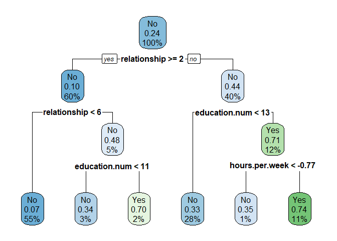

```r
rpart.plot(fit.tree)
```

```r
# Checking the order of variable importance
fit.tree$variable.importance
```

```
##   relationship marital.status  education.num            sex hours.per.week
##    728.2848475    291.4876067    269.4471066    183.0536463     80.4926251
##            age      workclass     occupation         fnlwgt           race
##     59.5906555     37.1966083      7.3510600      0.4682846      0.1560949
```

```r
pred.tree = predict(fit.tree, dataset.test, type = "class")
confMatBeforePruning=table(pred.tree,over50K.test)
#plotcp(fit.tree)
printcp(fit.tree)
```

```
##
## Classification tree:
## rpart(formula = over50K ~ ., data = dataset.train, method = "class",
##     cp = 0.01)
##
## Variables actually used in tree construction:
## [1] education.num  hours.per.week relationship
##
## Root node error: 2373/10000 = 0.2373
##
## n= 10000
##
##         CP nsplit rel error  xerror     xstd
## 1 0.105352      0   1.00000 1.00000 0.017928
## 2 0.016435      2   0.78930 0.79309 0.016472
## 3 0.010535      4   0.75643 0.76401 0.016235
## 4 0.010000      5   0.74589 0.76106 0.016211
```

```r
#calculate accuracy:
accuracy <- sum(diag(confMatBeforePruning))/sum(confMatBeforePruning)
accuracy
```

```
## [1] 0.8228424
```

```r
#calculate sensitivity:
tp <- confMatBeforePruning[2, 2]
fn <- confMatBeforePruning[2, 1]
sensitivity <- tp / (tp + fn)
sensitivity
```

```
## [1] 0.7430764
```

```r
#calculate specificity:
tn <- confMatBeforePruning[1, 1]
fp <- confMatBeforePruning[1, 2]

specificity <- tn / (tn + fp)
specificity
```

```
## [1] 0.8351428
```

```r
#calculate precision:
tp <- confMatBeforePruning[2, 2]
fp <- confMatBeforePruning[1, 2]

precision <- tp / (tp + fp)
precision
```

```
## [1] 0.4100534
```

```r
# Explicitly request the lowest cp value
fit.tree$cptable[which.min(fit.tree$cptable[,"xerror"]),"CP"]
```

```
## [1] 0.01
```

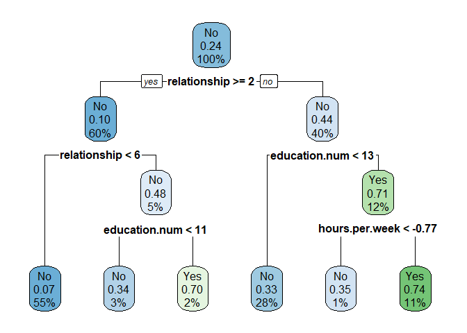

```r
bestcp <-fit.tree$cptable[which.min(fit.tree$cptable[,"xerror"]),"CP"]
pruned.tree <- prune(fit.tree, cp = bestcp)
rpart.plot(pruned.tree)
```

```r
pruned.tree
```

```
## n= 10000
##
## node), split, n, loss, yval, (yprob)
##       * denotes terminal node
##
##  1) root 10000 2373 No (0.76270000 0.23730000)
##    2) relationship>=1.5 6010  600 No (0.90016639 0.09983361)
##      4) relationship< 5.5 5513  360 No (0.93469980 0.06530020) *
##      5) relationship>=5.5 497  240 No (0.51710262 0.48289738)
##       10) education.num< 10.5 303  104 No (0.65676568 0.34323432) *
##       11) education.num>=10.5 194   58 Yes (0.29896907 0.70103093) *
##    3) relationship< 1.5 3990 1773 No (0.55563910 0.44436090)
##      6) education.num< 12.5 2790  923 No (0.66917563 0.33082437) *
##      7) education.num>=12.5 1200  350 Yes (0.29166667 0.70833333)
##       14) hours.per.week< -0.7738939 83   29 No (0.65060241 0.34939759) *
##       15) hours.per.week>=-0.7738939 1117  296 Yes (0.26499552 0.73500448) *
```

```r
# Alternate specification
pred.prune = predict(pruned.tree, dataset.test, type="class")
confMatAfterPruning=table(pred.prune, over50K.test)

#calculate accuracy:
accuracy <- sum(diag(confMatAfterPruning))/sum(confMatAfterPruning)
accuracy
```

```
## [1] 0.8228424
```

```r
#calculate sensitivity:
tp <- confMatAfterPruning[2, 2]
fn <- confMatAfterPruning[2, 1]
sensitivity <- tp / (tp + fn)
sensitivity
```

```
## [1] 0.7430764
```

```r
#calculate specificity:
tn <- confMatAfterPruning[1, 1]
fp <- confMatAfterPruning[1, 2]

specificity <- tn / (tn + fp)
specificity
```

```
## [1] 0.8351428
```

```r
#calculate precision:
tp <- confMatAfterPruning[2, 2]
fp <- confMatAfterPruning[1, 2]

precision <- tp / (tp + fp)
precision
```

```
## [1] 0.4100534
```

**Tree Explanation:** Root Node (Node 1): This is the starting point, representing the entire dataset. The majority class is ‘No,’ and the tree begins by considering the ‘relationship’ feature. Probabilities: (0.7627 for ‘No’, 0.2373 for ‘Yes’)

Splitting Node (Node 2): If the ‘relationship’ is greater than or equal to 1.5, the prediction is ‘No’ with a high probability. Otherwise, it moves to the next split. Probabilities: (0.9002 for ‘No’, 0.0998 for ‘Yes’)

Child Node 4:

If ‘relationship’ is less than 5.5, the prediction is ‘No’ with a high probability. This is a terminal node denoted by ‘*’, meaning no further splits occur. Probabilities: (0.9347 for ‘No’, 0.0653 for ‘Yes’)

Child Node 5:

If ‘relationship’ is greater than or equal to 5.5, it further considers the ‘education.num’ feature. Probabilities: (0.5171 for ‘No’, 0.4829 for ‘Yes’)

Child Node 10:

If ‘education.num’ is less than 10.5, the prediction is ‘No’ with a high probability. This is another terminal node.

Probabilities: (0.6568 for ‘No’, 0.3432 for ‘Yes’)

Child Node 11:

If ‘education.num’ is greater than or equal to 10.5, the prediction is ‘Yes’ with a high probability. This is also a terminal node. Probabilities: (0.2990 for ‘No’, 0.7010 for ‘Yes’)

Child Node 3:

If ‘relationship’ is less than 1.5, it further considers the ‘education.num’ and ‘hours.per.week’ features.

Probabilities: (0.5556 for ‘No’, 0.4444 for ‘Yes’)

Child Node 6:

If ‘education.num’ is less than 12.5, the prediction is ‘No’ with a high probability. Another terminal node. Probabilities: (0.6692 for ‘No’, 0.3308 for ‘Yes’)

Child Node 7:

If ‘education.num’ is greater than or equal to 12.5, it further considers the ‘hours.per.week’ feature.

Probabilities: (0.2917 for ‘No’, 0.7083 for ‘Yes’)

Child Node 14:

If ‘hours.per.week’ is less than -0.7738939, the prediction is ‘No’ with a high probability. This is a terminal node. Probabilities: (0.6506 for ‘No’, 0.3494 for ‘Yes’)

Child Node 15:

If ‘hours.per.week’ is greater than or equal to -0.7738939, the prediction is ‘Yes’ with a high probability. Another terminal node. Probabilities: (0.2650 for ‘No’, 0.7350 for ‘Yes’)

To summarize, the tree uses conditions based on the ‘relationship,’ ‘education.num,’ and ‘hours.per.week’ features to make predictions. The tree structure does not change even after pruning.

Finally, let’s set the cp to 0.0008 and observe the results.

```r
#CP=0.0008

fit.tree = rpart(over50K ~ ., data=dataset.train, method = "class", cp=0.0008)
fit.tree
```

```
## n= 10000
##
## node), split, n, loss, yval, (yprob)
##       * denotes terminal node
##
##       1) root 10000 2373 No (0.76270000 0.23730000)
##         2) relationship>=1.5 6010  600 No (0.90016639 0.09983361)
##           4) relationship< 5.5 5513  360 No (0.93469980 0.06530020)
##             8) education.num< 13.5 5196  248 No (0.95227098 0.04772902) *
##             9) education.num>=13.5 317  112 No (0.64668770 0.35331230)
##              18) hours.per.week< 0.3514391 182   44 No (0.75824176 0.24175824)
##                36) education.num< 14.5 141   26 No (0.81560284 0.18439716) *
##                37) education.num>=14.5 41   18 No (0.56097561 0.43902439)
##                  74) age< -0.4814398 9    0 No (1.00000000 0.00000000) *
##                  75) age>=-0.4814398 32   14 Yes (0.43750000 0.56250000)
##                   150) fnlwgt< -0.8144472 9    2 No (0.77777778 0.22222222) *
##                   151) fnlwgt>=-0.8144472 23    7 Yes (0.30434783 0.69565217) *
##              19) hours.per.week>=0.3514391 135   67 Yes (0.49629630 0.50370370)
##                38) fnlwgt< 1.18279 122   56 No (0.54098361 0.45901639)
##                  76) occupation>=10 88   32 No (0.63636364 0.36363636)
##                   152) fnlwgt>=-0.1757443 43   10 No (0.76744186 0.23255814) *
##                   153) fnlwgt< -0.1757443 45   22 No (0.51111111 0.48888889)
##                     306) education.num< 14.5 27   10 No (0.62962963 0.37037037)
##                       612) fnlwgt< -0.4369425 20    5 No (0.75000000 0.25000000) *
##                       613) fnlwgt>=-0.4369425 7    2 Yes (0.28571429 0.71428571) *
##                     307) education.num>=14.5 18    6 Yes (0.33333333 0.66666667) *
##                  77) occupation< 10 34   10 Yes (0.29411765 0.70588235) *
##                39) fnlwgt>=1.18279 13    1 Yes (0.07692308 0.92307692) *
##           5) relationship>=5.5 497  240 No (0.51710262 0.48289738)
##            10) education.num< 10.5 303  104 No (0.65676568 0.34323432)
##              20) age< -0.4447759 88   13 No (0.85227273 0.14772727) *
##              21) age>=-0.4447759 215   91 No (0.57674419 0.42325581)
##                42) hours.per.week< -0.4821409 62   14 No (0.77419355 0.22580645) *
##                43) hours.per.week>=-0.4821409 153   76 Yes (0.49673203 0.50326797)
##                  86) hours.per.week>=1.185019 8    0 No (1.00000000 0.00000000) *
##                  87) hours.per.week< 1.185019 145   68 Yes (0.46896552 0.53103448)
##                   174) education.num< 8.5 15    4 No (0.73333333 0.26666667) *
##                   175) education.num>=8.5 130   57 Yes (0.43846154 0.56153846)
##                     350) fnlwgt< -0.4575243 45   19 No (0.57777778 0.42222222)
##                       700) occupation>=5.5 17    4 No (0.76470588 0.23529412) *
```

[output cut: 161 more lines]

```
##                   252) fnlwgt< -0.6988463 113   46 Yes (0.40707965 0.59292035)
##                     504) occupation>=5.5 63   30 No (0.52380952 0.47619048)
##                      1008) age>=0.06851871 36   11 No (0.69444444 0.30555556)
##                        2016) fnlwgt>=-1.432379 28    5 No (0.82142857 0.17857143) *
##                        2017) fnlwgt< -1.432379 8    2 Yes (0.25000000 0.75000000) *
##                      1009) age< 0.06851871 27    8 Yes (0.29629630 0.70370370) *
##                     505) occupation< 5.5 50   13 Yes (0.26000000 0.74000000)
##                      1010) occupation< 4.5 10    4 No (0.60000000 0.40000000) *
##                      1011) occupation>=4.5 40    7 Yes (0.17500000 0.82500000) *
##                   253) fnlwgt>=-0.6988463 401   86 Yes (0.21446384 0.78553616)
##                     506) occupation>=14.5 9    3 No (0.66666667 0.33333333) *
##                     507) occupation< 14.5 392   80 Yes (0.20408163 0.79591837)
##                      1014) fnlwgt>=2.144569 9    3 No (0.66666667 0.33333333) *
##                      1015) fnlwgt< 2.144569 383   74 Yes (0.19321149 0.80678851) *
##                 127) education.num>=13.5 359   53 Yes (0.14763231 0.85236769) *
```

[figure not shown]

```r
rpart.plot(fit.tree)
```

**Tree Explanation:** The decision tree predicts binary outcomes (‘Yes’ or ‘No’) based on various features. The initial split is made on ‘relationship,’ with subsequent splits involving features such as ‘education.num,’ ‘hours.per.week,’ ‘fnlwgt,’ ‘occupation,’ ‘age,’ ‘workclass,’ and ‘race.’ The tree is moderately complex, and needs pruning.

```r
# Checking the order of variable importance
fit.tree$variable.importance
```

```
##   relationship  education.num marital.status            sex            age
##     728.284848     410.856339     292.158088     183.053646     171.842428
## hours.per.week         fnlwgt     occupation      workclass           race
##     170.576366     110.457305      75.510671      65.753223      14.497207
## native.country
##       4.310602
```

```r
pred.tree = predict(fit.tree, dataset.test, type = "class")
confMatBeforePruning=table(pred.tree,over50K.test)
#plotcp(fit.tree)
printcp(fit.tree)
```

```
##
## Classification tree:
## rpart(formula = over50K ~ ., data = dataset.train, method = "class",
##     cp = 8e-04)
##
## Variables actually used in tree construction:
## [1] age            education.num  fnlwgt         hours.per.week occupation
## [6] race           relationship   workclass
##
## Root node error: 2373/10000 = 0.2373
##
## n= 10000
##
##            CP nsplit rel error  xerror     xstd
## 1  0.10535188      0   1.00000 1.00000 0.017928
## 2  0.01643489      2   0.78930 0.79815 0.016512
## 3  0.01053519      4   0.75643 0.76865 0.016274
## 4  0.00400337      5   0.74589 0.75980 0.016200
## 5  0.00294985     11   0.72187 0.74463 0.016073
## 6  0.00280938     12   0.71892 0.73957 0.016030
## 7  0.00273915     17   0.70291 0.73957 0.016030
## 8  0.00263380     19   0.69743 0.73957 0.016030
## 9  0.00210704     23   0.68689 0.74294 0.016059
## 10 0.00189633     27   0.67678 0.73198 0.015965
## 11 0.00176991     36   0.65824 0.73578 0.015998
## 12 0.00168563     42   0.64686 0.73704 0.016008
## 13 0.00147493     47   0.63843 0.73873 0.016023
## 14 0.00126422     52   0.63043 0.74842 0.016105
## 15 0.00117994     72   0.60177 0.75221 0.016137
## 16 0.00105352     80   0.59166 0.75306 0.016144
## 17 0.00098328     84   0.58744 0.75179 0.016134
## 18 0.00084282     91   0.58028 0.75474 0.016158
## 19 0.00080000    105   0.56848 0.75643 0.016172
```

```r
#calculate accuracy:
accuracy <- sum(diag(confMatBeforePruning))/sum(confMatBeforePruning)
accuracy
```

```
## [1] 0.8216833
```

```r
#calculate sensitivity:
tp <- confMatBeforePruning[2, 2]
fn <- confMatBeforePruning[2, 1]
sensitivity <- tp / (tp + fn)
sensitivity
```

```
## [1] 0.6642939
```

```r
#calculate specificity:
tn <- confMatBeforePruning[1, 1]
fp <- confMatBeforePruning[1, 2]

specificity <- tn / (tn + fp)
specificity
```

```
## [1] 0.8596006
```

```r
#calculate precision:
tp <- confMatBeforePruning[2, 2]
fp <- confMatBeforePruning[1, 2]

precision <- tp / (tp + fp)
precision
```

```
## [1] 0.5326827
```

```r
# Explicitly request the lowest cp value
fit.tree$cptable[which.min(fit.tree$cptable[,"xerror"]),"CP"]
```

```
## [1] 0.001896334
```

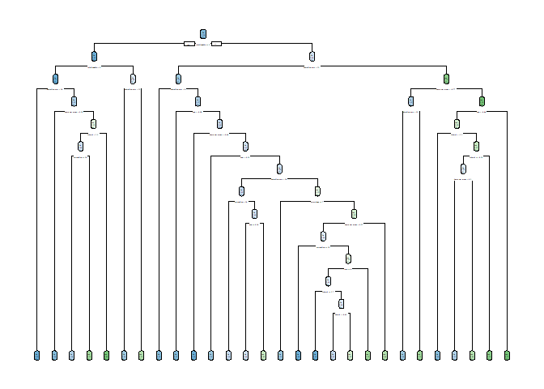

```r
bestcp <-fit.tree$cptable[which.min(fit.tree$cptable[,"xerror"]),"CP"]
pruned.tree <- prune(fit.tree, cp = bestcp)
rpart.plot(pruned.tree)
```

```r
pruned.tree
```

```
## n= 10000
##
## node), split, n, loss, yval, (yprob)
##       * denotes terminal node
##
##     1) root 10000 2373 No (0.76270000 0.23730000)
##       2) relationship>=1.5 6010  600 No (0.90016639 0.09983361)
##         4) relationship< 5.5 5513  360 No (0.93469980 0.06530020)
##           8) education.num< 13.5 5196  248 No (0.95227098 0.04772902) *
##           9) education.num>=13.5 317  112 No (0.64668770 0.35331230)
##            18) hours.per.week< 0.3514391 182   44 No (0.75824176 0.24175824) *
##            19) hours.per.week>=0.3514391 135   67 Yes (0.49629630 0.50370370)
##              38) fnlwgt< 1.18279 122   56 No (0.54098361 0.45901639)
##                76) occupation>=10 88   32 No (0.63636364 0.36363636) *
##                77) occupation< 10 34   10 Yes (0.29411765 0.70588235) *
##              39) fnlwgt>=1.18279 13    1 Yes (0.07692308 0.92307692) *
##         5) relationship>=5.5 497  240 No (0.51710262 0.48289738)
##          10) education.num< 10.5 303  104 No (0.65676568 0.34323432) *
##          11) education.num>=10.5 194   58 Yes (0.29896907 0.70103093) *
##       3) relationship< 1.5 3990 1773 No (0.55563910 0.44436090)
##         6) education.num< 12.5 2790  923 No (0.66917563 0.33082437)
##          12) education.num< 8.5 456   56 No (0.87719298 0.12280702) *
##          13) education.num>=8.5 2334  867 No (0.62853470 0.37146530)
##            26) age< -0.5914315 348   59 No (0.83045977 0.16954023) *
##            27) age>=-0.5914315 1986  808 No (0.59315206 0.40684794)
##              54) hours.per.week< -0.4821409 145   16 No (0.88965517 0.11034483) *
##              55) hours.per.week>=-0.4821409 1841  792 No (0.56979902 0.43020098)
##               110) age< -0.2247925 360  118 No (0.67222222 0.32777778) *
##               111) age>=-0.2247925 1481  674 No (0.54490209 0.45509791)
##                 222) education.num< 9.5 834  339 No (0.59352518 0.40647482)
##                   444) occupation< 10 585  220 No (0.62393162 0.37606838) *
##                   445) occupation>=10 249  119 No (0.52208835 0.47791165)
##                     890) age>=0.1418465 186   81 No (0.56451613 0.43548387) *
##                     891) age< 0.1418465 63   25 Yes (0.39682540 0.60317460) *
##                 223) education.num>=9.5 647  312 Yes (0.48222566 0.51777434)
##                   446) workclass>=6.5 96   31 No (0.67708333 0.32291667) *
##                   447) workclass< 6.5 551  247 Yes (0.44827586 0.55172414)
##                     894) hours.per.week< 0.2680811 326  160 No (0.50920245 0.49079755)
##                      1788) occupation>=14.5 11    1 No (0.90909091 0.09090909) *
##                      1789) occupation< 14.5 315  156 Yes (0.49523810 0.50476190)
##                        3578) race>=4 281  135 No (0.51957295 0.48042705)
##                          7156) fnlwgt>=1.715686 9    1 No (0.88888889 0.11111111) *
##                          7157) fnlwgt< 1.715686 272  134 No (0.50735294 0.49264706)
##                           14314) fnlwgt< -0.4124442 108   43 No (0.60185185 0.39814815) *
##                           14315) fnlwgt>=-0.4124442 164   73 Yes (0.44512195 0.55487805) *
##                        3579) race< 4 34   10 Yes (0.29411765 0.70588235) *
##                     895) hours.per.week>=0.2680811 225   81 Yes (0.36000000 0.64000000) *
##         7) education.num>=12.5 1200  350 Yes (0.29166667 0.70833333)
##          14) hours.per.week< -0.7738939 83   29 No (0.65060241 0.34939759)
##            28) education.num< 14.5 66   17 No (0.74242424 0.25757576) *
##            29) education.num>=14.5 17    5 Yes (0.29411765 0.70588235) *
##          15) hours.per.week>=-0.7738939 1117  296 Yes (0.26499552 0.73500448)
##            30) age< -0.4447759 165   77 Yes (0.46666667 0.53333333)
##              60) fnlwgt< -1.130514 14    2 No (0.85714286 0.14285714) *
##              61) fnlwgt>=-1.130514 151   65 Yes (0.43046358 0.56953642)
##               122) fnlwgt>=-0.3157913 106   53 No (0.50000000 0.50000000)
##                 244) hours.per.week< 0.1013651 54   20 No (0.62962963 0.37037037) *
##                 245) hours.per.week>=0.1013651 52   19 Yes (0.36538462 0.63461538) *
##               123) fnlwgt< -0.3157913 45   12 Yes (0.26666667 0.73333333) *
##            31) age>=-0.4447759 952  219 Yes (0.23004202 0.76995798) *
```

```r
# Alternate specification
pred.prune = predict(pruned.tree, dataset.test, type="class")
confMatAfterPruning=table(pred.prune, over50K.test)

#calculate accuracy:
accuracy <- sum(diag(confMatAfterPruning))/sum(confMatAfterPruning)
accuracy
```

```
## [1] 0.8292172
```

```r
#calculate sensitivity:
tp <- confMatAfterPruning[2, 2]
fn <- confMatAfterPruning[2, 1]
sensitivity <- tp / (tp + fn)
sensitivity
```

```
## [1] 0.6950268
```

```r
#calculate specificity:
tn <- confMatAfterPruning[1, 1]
fp <- confMatAfterPruning[1, 2]

specificity <- tn / (tn + fp)
specificity
```

```
## [1] 0.8592471
```

```r
#calculate precision:
tp <- confMatAfterPruning[2, 2]
fp <- confMatAfterPruning[1, 2]

precision <- tp / (tp + fp)
precision
```

```
## [1] 0.5249494
```

**Summary:**

*cp=0.1 results:*

The results indicates a moderate level of accuracy with a sensitivity that is higher than precision. It suggests a trade-off between correctly identifying positive instances and minimizing false positives.

*cp=0.01 results:*

The model with cp=0.01 shows slight improvement in accuracy and precision compared to the previous set. Sensitivity and specificity remain at similar levels.

*cp=0.0008 results (before pruning):* The model before pruning has a higher specificity, indicating a better ability to correctly identify negative instances. However, sensitivity is comparatively lower, suggesting a higher rate of false negatives.

*cp=0.0008 results (after pruning):* After pruning with the same cp value, the model shows an improvement in accuracy and sensitivity. However, precision has decreased slightly. Pruning likely helped in reducing overfitting, leading to better generalization.

### C4.5 Algorithm

C4.5 algorithm is an extension of the ID3 algorithm that chooses the attribute of the data that most effectively splits its set of samples into subsets, enriched in one class or the other. The splitting criterion is the normalized information gain.[4]

In this algorithm, we will be using the library ‘RWeka’ and the package ‘partykit’. The ‘RWeka’ package in R provides an interface to Weka, a popular collection of machine learning algorithms implemented in Java. And ‘partykit’ complements it by providing tools for visualizing and interpreting the resulting tree models.

We will test 3 different splits; 80-20, 70-30, 60-40, starting with 60-40:

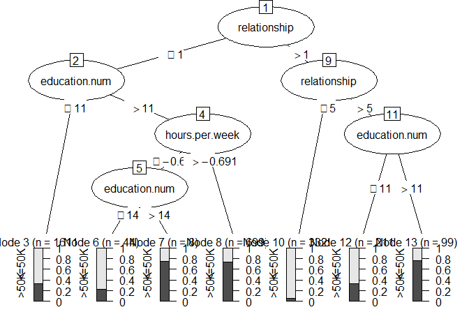

```r
#Note: Remove over50K & num_salary first
dataset <- subset(dataset, select = -c(over50K, num_salary))

sampleDataset <- dataset[1:10000, ]
set.seed(1234)
# Create a training set (60% of the data) and a testing set (40% of the data)
index <- createDataPartition(sampleDataset$salary, p = 0.6, list = FALSE)
training_set <- sampleDataset[index, ]
testing_set <- sampleDataset[-index, ]

# Train the model using the training set
C45Fit <- train(salary ~ ., method = "J48", data = training_set, tuneLength = 5)

# Extract the final model
final_model <- C45Fit$finalModel

# Plot the final model
 plot(final_model)
```

```r
  print(final_model)
```

```
## J48 pruned tree
## ------------------
##
## relationship <= 1
## |   education.num <= 11:  <=50K (1611.0/533.0)
## |   education.num > 11
## |   |   hours.per.week <= -0.690536
## |   |   |   education.num <= 14:  <=50K (44.0/10.0)
## |   |   |   education.num > 14:  >50K (8.0/2.0)
## |   |   hours.per.week > -0.690536:  >50K (699.0/185.0)
## relationship > 1
## |   relationship <= 5:  <=50K (3329.0/214.0)
## |   relationship > 5
## |   |   education.num <= 11:  <=50K (211.0/71.0)
## |   |   education.num > 11:  >50K (99.0/23.0)
##
## Number of Leaves  :  7
##
## Size of the tree :   13
```

**Tree Explanation:** The primary split is made based on the ‘relationship’ feature, which is a categorical variable representing the relationship status. This suggests that relationship status is considered crucial in determining income levels.

For instances where ‘relationship’ is less than or equal to 1, the decision tree further considers ‘education.num’ and ‘hours.per.week’.

If ‘relationship’ is greater than 1, the model looks at ‘education.num’ again and distinguishes income levels based on relationship status. This indicates that these features are considered significant predictors for this group.

```r
# Make predictions on the testing set
predictions <- predict(final_model, newdata = testing_set)

# Convert predictions and actual values to factors
predictions <- as.factor(predictions)
testing_set$salary <- as.factor(testing_set$salary)

# Create a confusion matrix
conf_matrix <- confusionMatrix(predictions, testing_set$salary)

# Print the confusion matrix
print(conf_matrix)
```

```
## Confusion Matrix and Statistics
##
##           Reference
## Prediction  <=50K  >50K
##      <=50K   2869   541
##      >50K     181   408
##
##                Accuracy : 0.8195
##                  95% CI : (0.8072, 0.8313)
##     No Information Rate : 0.7627
##     P-Value [Acc > NIR] : < 2.2e-16
##
##                   Kappa : 0.4263
##
##  Mcnemar's Test P-Value : < 2.2e-16
##
##             Sensitivity : 0.9407
##             Specificity : 0.4299
##          Pos Pred Value : 0.8413
##          Neg Pred Value : 0.6927
##              Prevalence : 0.7627
##          Detection Rate : 0.7174
##    Detection Prevalence : 0.8527
##       Balanced Accuracy : 0.6853
##
##        'Positive' Class :  <=50K
##
```

Now we test 70/30 split:

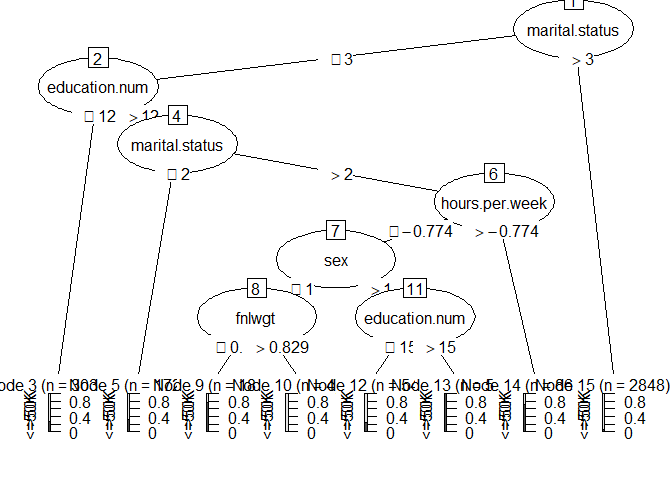

```r
# Create a training set (70% of the data) and a testing set (30% of the data)
index <- createDataPartition(sampleDataset$salary, p = 0.7, list = FALSE)
training_set <- sampleDataset[index, ]
testing_set <- sampleDataset[-index, ]

# Train the model using the training set
C45Fit <- train(salary ~ ., method = "J48", data = training_set, tuneLength = 5)

# Extract the final model
final_model <- C45Fit$finalModel

# Plot the final model
 plot(final_model)
```

```r
  print(final_model)
```

```
## J48 pruned tree
## ------------------
##
## marital.status <= 3
## |   education.num <= 12:  <=50K (3039.0/799.0)
## |   education.num > 12
## |   |   marital.status <= 2:  <=50K (172.0/54.0)
## |   |   marital.status > 2
## |   |   |   hours.per.week <= -0.773894
## |   |   |   |   sex <= 1
## |   |   |   |   |   fnlwgt <= 0.829325:  >50K (18.0/4.0)
## |   |   |   |   |   fnlwgt > 0.829325:  <=50K (4.0)
## |   |   |   |   sex > 1
## |   |   |   |   |   education.num <= 15:  <=50K (54.0/14.0)
## |   |   |   |   |   education.num > 15:  >50K (5.0)
## |   |   |   hours.per.week > -0.773894:  >50K (861.0/238.0)
## marital.status > 3:  <=50K (2848.0/153.0)
##
## Number of Leaves  :  8
##
## Size of the tree :   15
```

**Tree Explanation:** The tree predicts based on marital status, education, sex, hours worked per week, and fnlwgt. The tree first considers marital status and education, indicating their significant influence on income prediction. Lower education levels (12 or below) in combination with certain marital statuses tend to predict income below $50K.

For individuals with higher education levels (>12) and certain marital statuses, the tree considers the impact of hours worked per week. More hours worked per week generally correlate with higher income (>50K).

Within specific conditions of marital status, education, and hours worked, the tree differentiates predictions based on sex and fnlwgt. Males (sex=1) with lower fnlwgt are more likely to have higher income, while for females, the impact of education level becomes crucial.

```r
# Make predictions on the testing set
predictions <- predict(final_model, newdata = testing_set)

# Convert predictions and actual values to factors
predictions <- as.factor(predictions)
testing_set$salary <- as.factor(testing_set$salary)

# Create a confusion matrix
conf_matrix <- confusionMatrix(predictions, testing_set$salary)

# Print the confusion matrix
print(conf_matrix)
```

```
## Confusion Matrix and Statistics
##
##           Reference
## Prediction  <=50K  >50K
##      <=50K   2195   427
##      >50K      93   284
##
##                Accuracy : 0.8266
##                  95% CI : (0.8126, 0.84)
##     No Information Rate : 0.7629
##     P-Value [Acc > NIR] : < 2.2e-16
##
##                   Kappa : 0.4281
##
##  Mcnemar's Test P-Value : < 2.2e-16
##
##             Sensitivity : 0.9594
##             Specificity : 0.3994
##          Pos Pred Value : 0.8371
##          Neg Pred Value : 0.7533
##              Prevalence : 0.7629
##          Detection Rate : 0.7319
##    Detection Prevalence : 0.8743
##       Balanced Accuracy : 0.6794
##
##        'Positive' Class :  <=50K
##
```

Finally, the 80/20 split:

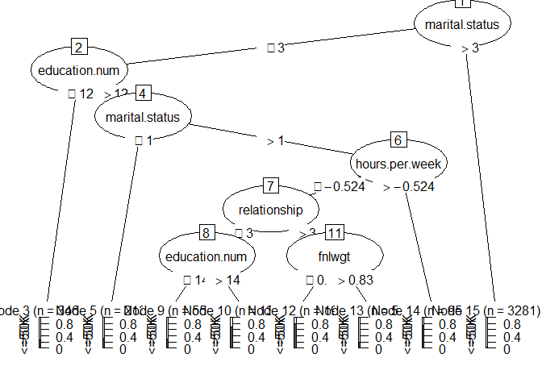

```r
##80/20 split:
# Set seed for reproducibility
set.seed(1234)

# Create a training set (80% of the data) and a testing set (20% of the data)
index <- createDataPartition(sampleDataset$salary, p = 0.8, list = FALSE)
training_set <- sampleDataset[index, ]
testing_set <- sampleDataset[-index, ]

# Train the model using the training set
C45Fit <- train(salary ~ ., method = "J48", data = training_set, tuneLength = 5)

# Extract the final model
final_model <- C45Fit$finalModel

# Plot the final model
 plot(final_model)
```

```r
 print(final_model)
```

```
## J48 pruned tree
## ------------------
##
## marital.status <= 3
## |   education.num <= 12:  <=50K (3460.0/932.0)
## |   education.num > 12
## |   |   marital.status <= 1:  <=50K (213.0/69.0)
## |   |   marital.status > 1
## |   |   |   hours.per.week <= -0.52382
## |   |   |   |   relationship <= 3
## |   |   |   |   |   education.num <= 14:  <=50K (55.0/16.0)
## |   |   |   |   |   education.num > 14:  >50K (13.0/4.0)
## |   |   |   |   relationship > 3
## |   |   |   |   |   fnlwgt <= 0.830376:  >50K (19.0/4.0)
## |   |   |   |   |   fnlwgt > 0.830376:  <=50K (5.0/1.0)
## |   |   |   hours.per.week > -0.52382:  >50K (955.0/248.0)
## marital.status > 3:  <=50K (3281.0/150.0)
##
## Number of Leaves  :  8
##
## Size of the tree :   15
```

For individuals with higher education levels (>12) and certain marital statuses, the tree considers the impact of hours worked per week. More hours worked per week generally correlate with higher income (>50K).

```r
# Make predictions on the testing set
predictions <- predict(final_model, newdata = testing_set)

# Convert predictions and actual values to factors
predictions <- as.factor(predictions)
testing_set$salary <- as.factor(testing_set$salary)

# Create a confusion matrix
conf_matrix <- confusionMatrix(predictions, testing_set$salary)

# Print the confusion matrix
print(conf_matrix)
```

```
## Confusion Matrix and Statistics
##
##           Reference
## Prediction  <=50K  >50K
##      <=50K   1443   274
##      >50K      82   200
##
##                Accuracy : 0.8219
##                  95% CI : (0.8044, 0.8385)
##     No Information Rate : 0.7629
##     P-Value [Acc > NIR] : 9.102e-11
##
##                   Kappa : 0.4279
##
##  Mcnemar's Test P-Value : < 2.2e-16
##
##             Sensitivity : 0.9462
##             Specificity : 0.4219
##          Pos Pred Value : 0.8404
##          Neg Pred Value : 0.7092
##              Prevalence : 0.7629
##          Detection Rate : 0.7219
##    Detection Prevalence : 0.8589
##       Balanced Accuracy : 0.6841
##
##        'Positive' Class :  <=50K
##
```

**Summary:** These results indicate that the C4.5 algorithm performed well, with relatively high accuracy and sensitivity across different training/testing splits. The precision and specificity also show a consistent performance in identifying positive instances.

**Recommendation:**

Generally speaking, most of the algorithms had a high accuracy. However, because our dataset is imbalanced, we must also take into account sensitivity, precision, and specificity.

Thus, we’ve believe that the ID3 algorithm is the best choice, as it appears to have a relatively good performance across different training/testing splits for our salary prediction dataset. ID3 consistently shows high accuracy, sensitivity, and precision.

### Evaluation and Comparison: Classification

## Classification:

**ID3 Algorithm Evaluation:**

|  | 80% Training, 20% Testing | 70% Training, 30% Testing | 60% Training, 40% Testing |
| --- | --- | --- | --- |
| Accuracy | 82 | 82 | 82 |
| Precision | 83 | 87 | 85 |
| Se nsitivity | 96 | 91 | 93 |
| Sp ecificity | 37 | 55 | 45 |

#### Analysis

*Accuracy:* The accuracy is consistent across the different splits, remaining at 82%. This suggests that the model is performing consistently in terms of overall correct predictions.

*Sensitivity:* Sensitivity measures the ability of the model to correctly identify positive instances (e.g., correct identification of a particular class). It shows a slight variation but generally remains high, ranging from 91% to 96%. This indicates that the model is good at capturing instances of the positive class.

*Specificity:* Specificity measures the ability of the model to correctly identify negative instances. It varies more noticeably, from 37% to 55%. A lower specificity suggests that the model may struggle more with correctly identifying negative instances.

*Precision:* Precision is the proportion of true positive predictions out of all positive predictions. It ranges from 83% to 87%, showing relatively consistent performance in terms of precision across the different training-testing splits.

In summary, the model seems to have consistent accuracy, but there are variations in how well it performs in terms of sensitivity and specificity across different training-testing splits.

**CART Algorithm Evaluation:**

|  | cp = 0.1 | cp = 0.01 | cp = 0 . 0008 Before/ After Pruning |
| --- | --- | --- | --- |
| Accuracy | 81 | 82 | 82/83 |
| P recision | 37 | 41 | 53/52 |
| S e n sitivity | 73 | 74 | 66/70 |
| S p e cificity | 83 | 84 | 86/86 |

#### Analysis:

*Accuracy:* The accuracy ranges from 81% to 83%, showing stability across different cp values.

*Sensitivity:* Sensitivity improves from 66% (before pruning) to 70% (after pruning), indicating better identification of positive instances.

*Specificity:* Specificity is relatively stable, with values ranging from 83% to 86%.

*Precision:* Precision varies between 37% and 53%, with the highest precision achieved before pruning.

**C4.5 Algorithm Evaluation:**

|  | 80% T raining, 20% Testing | 70% T raining, 30% Testing | 60% T raining, 40% Testing |
| --- | --- | --- | --- |
| Accuracy | 82 | 83 | 82 |
| P recision | 84 | 84 | 84 |
| S e n sitivity | 95 | 96 | 94 |
| S p e cificity | 42 | 40 | 43 |

#### Analysis:

*Accuracy:* The accuracy is relatively stable across different training/testing splits, ranging from 82% to 83%.

*Sensitivity:* Sensitivity is high, indicating that the algorithm performs well in identifying positive instances.

*Specificity:* Specificity is moderate, suggesting that the algorithm has some difficulty correctly identifying negative instances.

*Precision:* Precision is consistent at 84%, implying that when the algorithm predicts the positive class, it is correct 84% of the time.

In summary, the model appears to perform consistently across different training/testing splits. It exhibits good sensitivity and precision, but there’s room for improvement in specificity.

# Findings

To get accurate results, we have applied many preprocessing techniques, such as data cleaning and data transformation. We have removed all null, missing values and outliers that can badly affect the results, and finally, we have applied data transformation techniques–encoding and normalization–to give them equal weight and to facilitate data handling during data mining tasks.

For classification, we used the decision tree approach to build our model, and evaluated 3 different algorithms; ID3, C4.5, and CART. For the ID3 and C4.5 algorithms, we tried 3 different sizes of training and testing data to achieve the best outcome for construction and evaluation. For the CART algorithm, we changed the cp value 3 times, while observing and comparing the results.

[figure not shown]

C4.5 70/30 Tree

What this tells us is that there’s a great emphasis on education level and marital status in the work field. Employers can gain insights into which factors, such as education level, marital status, hours.per.week, and so on, are influential in determining whether an individual earns above or below a certain threshold. Moreover, knowing the influential factors can guide employers in developing targeted recruitment strategies. So if certain education levels or marital statuses are associated with higher income, employers can focus their recruitment efforts on individuals with those characteristics.

As for clustering, the clustering process involved analyzing the dataset to group similar data points together. K-means clustering was used with different values of k = 2, 3, and 4. Each clustering iteration was evaluated using various metrics like silhouette scores, within-cluster sum of squares (WCSS), BCubed precision, and recall.

Silhouette Method: The silhouette method indicated different average silhouette scores for different values of k. Optimal k may vary based on the silhouette method, suggesting k=3 as having the highest silhouette width.

Elbow Method: The elbow method demonstrated a significant drop in WCSS up to k=2, after which the decrease slowed down considerably. This implies that k=2 could be an optimal choice based on the within-cluster sum of squares.

**Evaluation of Clustering Results:**

K=3 seemed to strike a balance between silhouette width and reasonable precision and recall. K=4 showed high precision but at the expense of lower recall, possibly due to fragmentation into smaller clusters. K=2 Notably excelled in recall, implying its ability to encompass a wider range of relevant instances.

**Clustering vs Classification** Based on our results and the nature of our dataset, we believe that classification had a better performance than clustering.

# References

[1]Chen, J. (no date) How a histogram works to display data, Investopedia. Available at: https://www.investopedia.com/terms/h/histogram.asp (Accessed: 28 November 2023).

[2]Healy, Y.H. and C. (no date) Barplot, Barplot – from Data to Viz. Available at: https://www.data-to-viz.com/graph/barplot.html (Accessed: 28 November 2023).

[3]Synergy Codes (2022) What is a density plot? definition, importance, and examples – glossary, Synergy Codes. Available at: https://synergycodes.com/glossary/what-is-density-plot/ (Accessed: 28 November 2023).

[4]Khanna, N. (2021) J48 classification (C4.5 algorithm) in a Nutshell, Medium. Available at: https://medium.com/@nilimakhanna1/j48-classification-c4-5-algorithm-in-a-nutshell-24c50d20658e (Accessed: 30 November 2023).